# Predictive Modelling of Hearing Effect of Bioage

Landy Qu & Tom Naber

March 19, 2026

# 1 Set-up & Data import

## 1.1 Import Packages & Set Flags

## 1.2 Print params for .md

```r
kable(as.data.frame(unclass(params)))
```

| hearing_var | telolength | global_discrete | store_model_results | load_model_results | keep_models | construct_data | use_kwon_bioage | use_advance_bioages | save_figures | run_optional_chunks | global_k | global_folds | global_repeats | single_column_width | double_column_width | confounders |
| --- | --- | --- | --- | --- | --- | --- | --- | --- | --- | --- | --- | --- | --- | --- | --- | --- |
| FI_high | TRUE | TRUE | FALSE | TRUE | FALSE | FALSE | FALSE | FALSE | FALSE | FALSE | 15 | 10 | 10 | 3.19 | 6.96 | gender_smoking_race_education_gender, race |

## 1.3 Import Data

.xpt files are loaded, then stripped of extension. The year is stored. All files per year are merged horizontally (adding columns) by the SEQN column. Each yearly merged file is then added vertically (stacked rows).

```r
import_nhanes_data <- function(path) {
  path
  files <- list.files(
    path,
    pattern = "\\.xpt$",
    full.names = TRUE,
    ignore.case = TRUE
  )

  meta <- data.table(file  = files,
                     year = str_extract(tools::file_path_sans_ext(basename(files)), "\\d{4}-\\d{4}$"))

  meta[, dt := lapply(file, \(f) as.data.table(read_xpt(f)))]
  by_year <- split(meta$dt, meta$year)

  as.data.frame(rbindlist(
    lapply(by_year, \(dts)
           Reduce(\(x, y) merge(
             x, y, by = "SEQN", all = TRUE
           ), dts)),
    fill = TRUE,
    use.names = TRUE,
    idcol = "year"
  ))
}

if (isTRUE(params$construct_data)) {
  df_raw <- import_nhanes_data(here("Data", "Raw data"))
} else {
  df_raw <- read.csv(here("Data", "dataset_bioage.csv"))
}
```

```r
      filename_constructor <- function(params) {
        parts <- c(
          params$hearing_var,
          paste0("K=", params$global_k),
          if (params$global_discrete) "discrete" else NULL,
          if (params$telolength) "telolength" else NULL,
          paste0(params$global_repeats, "r×", params$global_folds, "f")
        )

        here::here("Output", "HTML", paste(parts, collapse = "_"))
      }
```

### 1.3.1 Insert Kwon data

If `use_kwon_bioage` is `TRUE`, load NHANES4 (cloned from Kwon’s GitHub), ensure sampleIDs that are in BOTH Kwon’s data and in the raw data are retained, then select only the columns in NHANES4 and remove bioage measures if they’re in the raw_data file (either composed from scratch or from Landy).

```r
load_kwon_data <- function() {
  library(BioAge)

  #HD using NHANES (separate training for men and women)
  hd = hd_nhanes(
    biomarkers = c(
      "albumin",
      "alp",
      "lncrp",
      "totchol",
      "lncreat",
      "hba1c",
      "sbp",
      "bun",
      "uap",
      "lymph",
      "mcv",
      "wbc"
    )
  )

  #KDM bioage using NHANES (separate training for men and women)
  kdm = kdm_nhanes(
    biomarkers = c(
      "albumin",
      "alp",
      "lncrp",
      "totchol",
      "lncreat",
      "hba1c",
      "sbp",
      "bun",
      "uap",
      "lymph",
      "mcv",
      "wbc"
    )
  )

  #phenoage using NHANES
  phenoage = phenoage_nhanes(
    biomarkers = c(
      "albumin_gL",
      "alp",
      "lncrp",
      "totchol",
      "lncreat_umol",
      "hba1c",
      "sbp",
      "bun",
      "uap",
      "lymph",
      "mcv",
      "wbc"
    )
  )

  merge(hd$data, kdm$data) %>% merge(., phenoage$data)
}

if (isTRUE(params$use_kwon_bioage)) {
  NHANES4 <- load_kwon_data()
  df_raw <- df_raw %>%
    select(-any_of(c("hd", "hd_log", "kdm", "phenoage")))

  df_raw <- df_raw %>% filter(sampleID %in% NHANES4$sampleID) %>% arrange(sampleID) %>% relocate(sampleID, .before = 1)
  NHANES4 <- NHANES4 %>% filter(sampleID %in% df_raw$sampleID) %>% arrange(sampleID)

  df_raw <- df_raw %>%
    left_join(NHANES4 %>% select(any_of(c(
      "sampleID", setdiff(names(NHANES4), names(df_raw))
    ))), by = "sampleID")
}
```

## 1.4 Use advance versions

Replaces phenoage/kdm with ‘advance’ versions, which are the difference between age and the bioage measured.

```r
if (isTRUE(params$use_kwon_bioage) && isTRUE(params$use_advance_bioages)) {
  df_raw <- df_raw %>%
    rename("phenoage_bak" = phenoage,
           "kdm_bak" = kdm) %>%
    mutate(phenoage = phenoage_advance,
           kdm = kdm_advance)
} else if (isFALSE(params$use_kwon_bioage) && isTRUE(params$use_advance_bioages)) {
  stop("Set use_kwon_bioage to TRUE when using use_advance_bioages")
}
```

# 2 Data Preprocessing

## 2.1 Unpack confounders list

We take the param value for confounders and build one lists with all included interactions with age and one with just the variables

```r
confounder_interactions <- trimws(strsplit(params$confounders, "_")[[1]])
confounder_vars <- confounder_interactions[!grepl(",", confounder_interactions)]
```

## 2.2 Remove Unnecessary Columns & Rename

We filter out education level 9 because there are only 2 occurrences. Smoking has more than 2 levels but we only need two. Race 1 (Mexican American) and 2 (other Hispanic) are merged. Income could be added but we’d have to exclude 12, 13, 77, 99 and missing. 12 is over 20k, 13 is under 20k, 77 is refused and 99 is don’t know. This would drop the size of the data set by about 20%.

Code levels: **Smoking** 1. Smoker (L1) 2. Non-smoker L2) 7. Refused 9. Don’t know **Gender** 1. Male (L1) 2. Female (L2) **Race** 1. Mexican/other Hispanic (L1) 3. White (L2) 4. Black (L3) 5. Other (L4) **Education** 1. Less than 9th grade (L1) 2. 9-11th grade (includes 12th grade with no diploma) (L2) 3. High school (L3) 4. Some college or AA degree (L4) 5. College graduate or above 7. Refused 9. Don’t know

```r
df <- df_raw %>%
  select(
    age,
    all_of(confounder_vars),
    kdm,
    phenoage,
    hd_log,
    telolength,
    all_of(params$hearing_var),
    albumin_gL,
    alp,
    bun,
    creat,
    crp,
    glucose,
    hba1c,
    lymph,
    mcv,
    rdw,
    sbp,
    totchol,
    wbc,
    uap
  ) %>%
  filter(education != 9, smoking %in% c(1, 2)) %>%
  mutate(
    gender = factor(gender),
    smoking = factor(smoking),
    race = case_when(race == 2 ~ 1, TRUE ~ race),
    race = factor(race),
    education = factor(education),
    phenoage_advance = phenoage-age)
```

## 2.3 Optionally only include telolength rows

```r
if (isTRUE(params$telolength)) {
  df <- df %>%
    filter(
      !is.na(telolength)
    )
}
```

## 2.4 Prepare age group column

```r
df <- df %>% mutate(
  age_group = case_when(
    age >= 20 & age < 30 ~ "20-30",
    age >= 30 & age < 40 ~ "30-40",
    age >= 40 & age < 50 ~ "40-50",
    age >= 50 & age < 60 ~ "50-60",
    age >= 60 & age < 70 ~ "60-70",
    isFALSE(params$telolength) & age >= 70 ~ "70+",
  ), confounders = interaction(gender, smoking)
)
```

# 3 Modelling

## 3.1 K fold splitting

### 3.1.1 Fold-maker function

This function takes the indices of rows each age group, randomizes them, then assigns numbers of 1-10. We could integrate this into the k-fold cross validation function, but by doing it separately it’s easier to inspect any possible issues.

```r
make_repeated_folds <- function(data, grouping_variable, k, repeats) {
  # helper function to make random k-fold indices for one repeat
  kfold_split_stratified <- function(k, grouping_variable = NULL) {
    grouping_variable <- as.integer(as.factor(grouping_variable)) # convert factor of age_group to number
    group_len <- length(unique(grouping_variable)) # check number of age groups
    observations <- length(grouping_variable) # check how many observations there are to get a number

    indices <- numeric() # empty list to add fold numbers to

    for (l in 1:group_len) {
      # run loop for each age group
      indices_grouping_variable <- which(grouping_variable == l) # find which rows have the age group
      indices <- c(indices, sample(indices_grouping_variable)) # randomly shuffle indegrouping_variablees within each age group, so that the numbers 1-10 will equally be spaced throughout the age group, creating even age group distributions in each fold
    }

    bins <- rep(observations) # create an output with the length of the number of observations
    bins[indices] <- rep(1:k, ceiling(observations / k))[1:observations] # using the random order, 1-10 is repeated until we've reached the last observation
    return(bins) # return shuffled k-folds, which is pasted into a new column in 'data'
  }

  for (i in 1:repeats) {
    # per repeat, make shuffled k-folds of indices in a new column
    data[[paste0("fold_r", i)]] <- kfold_split_stratified(k = k, grouping_variable = data[[grouping_variable]]) # writes k-folds to a new column for each repeat
  }

  return(data) # return the dataframe with a k-fold column per repeat
}
```

### 3.1.2 Make folds

If k-fold validation throws errors that testing data contains factor levels that weren’t in the training data, it may be needed to make an interaction variable of age_group with the problematic factor (or condense levels) to ensure the smaller factor levels are represented in each fold.

```r
set.seed(2)
df <- make_repeated_folds(
  data = df,
  grouping_variable = "age_group",
  k = params$global_folds,
  repeats = params$global_repeats
)
```

## 3.2 Formula building

### 3.2.1 Formula builder function

The `k` determines the number of functions (linear or non-linear).The parameter with the lowest degrees of freedom (DF) determines the maximum basis dimensions (k in mgcv). Albumin has 26 distinct levels, so the maximal k value/number of basic functions, equivalent to the DF, is 25 if each level is in each fold. We must compute the DF for each fold and pick the lowest to avoid errors. The GAM is a composite of all these underlying functions, with different weights for each function.

- `k`: number of basis functions.
- `max_k`: sets k to the theoretical limit for each parameter (DF), note that for non-integers, like the bioage measures, this will be equivalent to the length of the dataframe minus one.
- `auto_limit_k`: if k exceeds the DF for a parameter (e.g., if k > 25 for albumin), it will automatically be limited to the DF.

```r
formula_generator <- function(data,
                              formulas,
                              confounders = NULL,
                              k = 25,
                              max_k = FALSE,
                              auto_limit_k = FALSE,
                              equal_wiggliness = TRUE,
                              stepdown = FALSE) {
  fold_columns <- grep("^fold_r", names(data), value = TRUE) # initialize the repeat columns with folds
  folds =   1:length(fold_columns) # get each unique fold number in folds
  formula_list <- list() # initialize a list to store the compiled formulas in

  DF_store <- tibble(
    predictor = character(),
    DF = numeric()
  )

  for (formula in formulas) {
    predictors <- trimws(unlist(strsplit(formula, ","))) # unlist, split by comma, and get rid of white spaces for the current predictors string
    sm_terms <- list()

    # make a term for each predictor
    for (predictor in predictors) {
      if (predictor %in% DF_store$predictor) {
        DF <- DF_store$DF[DF_store$predictor == predictor]
      } else {
      DF_list <- list() # initialize a list to store the DF for each fold in

      for (rep in fold_columns) {
        for (fold in folds) {
          DF_list <- append(DF_list, length(unique(data[data[[rep]] != fold, ][[predictor]]))) # store the DF for each fold in each repeat in a list
        }
      }
      DF <- min(unlist(DF_list)) - 1 # pick the smallest value in the list and subtract 1 to obtain degrees of freedom
      DF_store <- bind_rows(DF_store, tibble(predictor = predictor, DF = DF)) # Store in list
      }

      if (max_k) {
        k_formula <- DF
      } else {
        k_formula <- k
      }

      if (auto_limit_k) {
        if (k_formula > DF) {
          k_formula <- DF
        }
      }
      if ((predictor == "age") && (equal_wiggliness)) {
        sm_terms <- append(sm_terms, paste0("s(age, k = ", k_formula, ")"))


        if (!is.null(confounders)) {
          for (i in seq_along(confounders)) {
            confounder <- confounders[i]
            sm_terms <- append(
              sm_terms,
              paste0(
                "s(age, ",
                confounder,
                ", bs = 'sz', k = ",
                k_formula,
                ", id = ",
                i,
                ") "
              )
            )
          }
        }
      } else if ((predictor == "age") && !(equal_wiggliness)) {
        sm_terms <- append(sm_terms, paste0("s(age, k = ", k_formula, ")"))
        if (!is.null(confounders)) {
          for (confounder in confounders) {
            sm_terms <- append(sm_terms,
                               paste0(
                                 "s(age, ",
                                 confounder,
                                 ", bs = 'sz', k = ",
                                 k_formula,
                                 ") "
                               ))
          }
        }
      }
      else {
        sm_terms <- append(sm_terms,
                           paste0("s(", predictor, ", k = ", k_formula, ")"))
      }
    }
    formula_list <- append(formula_list, paste(params$hearing_var, "~", paste(unlist(sm_terms), collapse = " + "))) # put predictor terms in formula and separate by +
    if (isTRUE(stepdown) && formula == "age") {

      if ("age" %in% DF_store$predictor) {
        DF <- DF_store$DF[DF_store$predictor == "age"]
      } else {
        DF_list <- list()
        for (rep in fold_columns) {
          for (fold in folds) {
            DF_list = append(DF_list, length(unique(data[data[[rep]] != fold, ][["age"]])))
          }
        }

        DF <- min(unlist(DF_list)) - 1
        DF_store <- bind_rows(DF_store, tibble(predictor = "age", DF = DF)) # Store in list
      }
      if (max_k) {
        k_formula <- DF
      } else {
        k_formula <- k
      }

      if (auto_limit_k) {
        if (k_formula > DF) {
          k_formula <- DF
        }
      }
      for (i in seq_along(confounders)) {
        sm_terms <- list()
        sm_terms <- append(sm_terms, paste0("s(age, k = ", k_formula, ")"))
        constrained_confounders <- confounders[-i]

        for (j in seq_along(constrained_confounders)) {
          constrained_confounder <- constrained_confounders[j]
          sm_terms <- append(
            sm_terms,
            paste0(
              "s(age, ",
              constrained_confounder,
              ", bs = 'sz', k = ",
              k_formula,
              ", id = ",

              j,
              ") "
            )
          )
        }

        formula_list <- append(formula_list, paste(params$hearing_var, "~", paste(unlist(sm_terms), collapse = " + ")))
      }
    }
  }
  return(formula_list)
}
```

### 3.2.2 Extract variables from formula function

```r
extract_predictors <- function(formula, collapse = "") {
  confounders <- confounder_vars

  s_terms <- unlist(str_extract_all(formula, "s\\([^\\)]*\\)"))
  keep    <- !str_detect(s_terms, paste0("\\b(", paste(confounders, collapse = "|"), ")\\b"))
  str_match(s_terms[keep], "^s\\(\\s*([^,\\)\\s]+)")[, 2]
}
```

### 3.2.3 Generate formulas bioage

```r
formula_list_bioage <- formula_generator(
  data = df,
  k = params$global_k,
  auto_limit_k = TRUE,
  equal_wiggliness = TRUE,
  formulas = c(
    "age",
    "age, phenoage",
    "age, kdm",
    "age, hd_log",
    if (isTRUE(params$telolength))
      "age, telolength"
    else
      NULL
  ),
  confounders = confounder_interactions
)

as.data.frame(cbind(Formulas = unlist(formula_list_bioage))) %>% kable("html", caption = "Bioage Formulas") %>%
  kable_styling(
    bootstrap_options = c("striped", "hover"),
    full_width = FALSE,
    position = "left",
    font_size = 12,
    fixed_thead = TRUE
  ) %>%
  scroll_box(width = "100%", height = "400px")
```

Bioage Formulas

| Formulas |
| --- |
| FI_high ~ s(age, k = 15) + s(age, gender, bs = ‘sz’, k = 15, id = 1) + s(age, smoking, bs = ‘sz’, k = 15, id = 2) + s(age, race, bs = ‘sz’, k = 15, id = 3) + s(age, education, bs = ‘sz’, k = 15, id = … |
| FI_high ~ s(age, k = 15) + s(age, gender, bs = ‘sz’, k = 15, id = 1) + s(age, smoking, bs = ‘sz’, k = 15, id = 2) + s(age, race, bs = ‘sz’, k = 15, id = 3) + s(age, education, bs = ‘sz’, k = 15, id = … |
| FI_high ~ s(age, k = 15) + s(age, gender, bs = ‘sz’, k = 15, id = 1) + s(age, smoking, bs = ‘sz’, k = 15, id = 2) + s(age, race, bs = ‘sz’, k = 15, id = 3) + s(age, education, bs = ‘sz’, k = 15, id = … |
| FI_high ~ s(age, k = 15) + s(age, gender, bs = ‘sz’, k = 15, id = 1) + s(age, smoking, bs = ‘sz’, k = 15, id = 2) + s(age, race, bs = ‘sz’, k = 15, id = 3) + s(age, education, bs = ‘sz’, k = 15, id = … |
| FI_high ~ s(age, k = 15) + s(age, gender, bs = ‘sz’, k = 15, id = 1) + s(age, smoking, bs = ‘sz’, k = 15, id = 2) + s(age, race, bs = ‘sz’, k = 15, id = 3) + s(age, education, bs = ‘sz’, k = 15, id = … |

### 3.2.4 Generate formulas biomarkers

```r
formula_list_biomarkers <- formula_generator(
  data = df,
  k = params$global_k,
  auto_limit_k = TRUE,
  equal_wiggliness = TRUE,
  formulas = c(
    "age",
    "age, phenoage",
    "age, albumin_gL",
    "age, alp",
    "age, creat",
    "age, glucose",
    "age, crp",
    "age, lymph",
    "age, mcv",
    "age, rdw",
    "age, wbc",
    "age, sbp",
    "age, bun",
    "age, totchol",
    "age, hba1c",
    "age, uap",
    "age, crp, hba1c, albumin_gL",
    "age, crp, hba1c, albumin_gL, phenoage"
  ),
  confounders = confounder_interactions
)

as.data.frame(cbind(Formulas = unlist(formula_list_biomarkers))) %>% kable("html", caption = "Biomarker Formulas") %>%
  kable_styling(
    bootstrap_options = c("striped", "hover"),
    full_width = FALSE,
    position = "left",
    font_size = 12,
    fixed_thead = TRUE
  ) %>%
  scroll_box(width = "100%", height = "400px")
```

Biomarker Formulas

| Formulas |
| --- |
| FI_high ~ s(age, k = 15) + s(age, gender, bs = ‘sz’, k = 15, id = 1) + s(age, smoking, bs = ‘sz’, k = 15, id = 2) + s(age, race, bs = ‘sz’, k = 15, id = 3) + s(age, education, bs = ‘sz’, k = 15, id = … |
| FI_high ~ s(age, k = 15) + s(age, gender, bs = ‘sz’, k = 15, id = 1) + s(age, smoking, bs = ‘sz’, k = 15, id = 2) + s(age, race, bs = ‘sz’, k = 15, id = 3) + s(age, education, bs = ‘sz’, k = 15, id = … |
| FI_high ~ s(age, k = 15) + s(age, gender, bs = ‘sz’, k = 15, id = 1) + s(age, smoking, bs = ‘sz’, k = 15, id = 2) + s(age, race, bs = ‘sz’, k = 15, id = 3) + s(age, education, bs = ‘sz’, k = 15, id = … |
| FI_high ~ s(age, k = 15) + s(age, gender, bs = ‘sz’, k = 15, id = 1) + s(age, smoking, bs = ‘sz’, k = 15, id = 2) + s(age, race, bs = ‘sz’, k = 15, id = 3) + s(age, education, bs = ‘sz’, k = 15, id = … |
| FI_high ~ s(age, k = 15) + s(age, gender, bs = ‘sz’, k = 15, id = 1) + s(age, smoking, bs = ‘sz’, k = 15, id = 2) + s(age, race, bs = ‘sz’, k = 15, id = 3) + s(age, education, bs = ‘sz’, k = 15, id = … |
| FI_high ~ s(age, k = 15) + s(age, gender, bs = ‘sz’, k = 15, id = 1) + s(age, smoking, bs = ‘sz’, k = 15, id = 2) + s(age, race, bs = ‘sz’, k = 15, id = 3) + s(age, education, bs = ‘sz’, k = 15, id = … |
| FI_high ~ s(age, k = 15) + s(age, gender, bs = ‘sz’, k = 15, id = 1) + s(age, smoking, bs = ‘sz’, k = 15, id = 2) + s(age, race, bs = ‘sz’, k = 15, id = 3) + s(age, education, bs = ‘sz’, k = 15, id = … |
| FI_high ~ s(age, k = 15) + s(age, gender, bs = ‘sz’, k = 15, id = 1) + s(age, smoking, bs = ‘sz’, k = 15, id = 2) + s(age, race, bs = ‘sz’, k = 15, id = 3) + s(age, education, bs = ‘sz’, k = 15, id = … |
| FI_high ~ s(age, k = 15) + s(age, gender, bs = ‘sz’, k = 15, id = 1) + s(age, smoking, bs = ‘sz’, k = 15, id = 2) + s(age, race, bs = ‘sz’, k = 15, id = 3) + s(age, education, bs = ‘sz’, k = 15, id = … |
| FI_high ~ s(age, k = 15) + s(age, gender, bs = ‘sz’, k = 15, id = 1) + s(age, smoking, bs = ‘sz’, k = 15, id = 2) + s(age, race, bs = ‘sz’, k = 15, id = 3) + s(age, education, bs = ‘sz’, k = 15, id = … |
| FI_high ~ s(age, k = 15) + s(age, gender, bs = ‘sz’, k = 15, id = 1) + s(age, smoking, bs = ‘sz’, k = 15, id = 2) + s(age, race, bs = ‘sz’, k = 15, id = 3) + s(age, education, bs = ‘sz’, k = 15, id = … |
| FI_high ~ s(age, k = 15) + s(age, gender, bs = ‘sz’, k = 15, id = 1) + s(age, smoking, bs = ‘sz’, k = 15, id = 2) + s(age, race, bs = ‘sz’, k = 15, id = 3) + s(age, education, bs = ‘sz’, k = 15, id = … |
| FI_high ~ s(age, k = 15) + s(age, gender, bs = ‘sz’, k = 15, id = 1) + s(age, smoking, bs = ‘sz’, k = 15, id = 2) + s(age, race, bs = ‘sz’, k = 15, id = 3) + s(age, education, bs = ‘sz’, k = 15, id = … |
| FI_high ~ s(age, k = 15) + s(age, gender, bs = ‘sz’, k = 15, id = 1) + s(age, smoking, bs = ‘sz’, k = 15, id = 2) + s(age, race, bs = ‘sz’, k = 15, id = 3) + s(age, education, bs = ‘sz’, k = 15, id = … |
| FI_high ~ s(age, k = 15) + s(age, gender, bs = ‘sz’, k = 15, id = 1) + s(age, smoking, bs = ‘sz’, k = 15, id = 2) + s(age, race, bs = ‘sz’, k = 15, id = 3) + s(age, education, bs = ‘sz’, k = 15, id = … |
| FI_high ~ s(age, k = 15) + s(age, gender, bs = ‘sz’, k = 15, id = 1) + s(age, smoking, bs = ‘sz’, k = 15, id = 2) + s(age, race, bs = ‘sz’, k = 15, id = 3) + s(age, education, bs = ‘sz’, k = 15, id = … |
| FI_high ~ s(age, k = 15) + s(age, gender, bs = ‘sz’, k = 15, id = 1) + s(age, smoking, bs = ‘sz’, k = 15, id = 2) + s(age, race, bs = ‘sz’, k = 15, id = 3) + s(age, education, bs = ‘sz’, k = 15, id = … |
| FI_high ~ s(age, k = 15) + s(age, gender, bs = ‘sz’, k = 15, id = 1) + s(age, smoking, bs = ‘sz’, k = 15, id = 2) + s(age, race, bs = ‘sz’, k = 15, id = 3) + s(age, education, bs = ‘sz’, k = 15, id = … |

### 3.2.5 Generate formulas confounders

```r
if (isFALSE(params$telolength)) {
formula_list_confounders <- formula_generator(
  data = df,
  k = params$global_k,
  auto_limit_k = TRUE,
  equal_wiggliness = TRUE,
  formulas = c("age", "age, phenoage"),
  confounders = confounder_interactions,
  stepdown = TRUE
)
}
```

## 3.3 Repeated k-fold modeling

### 3.3.1 Repeated k-fold validation function per age group

```r
cross_validation <- function(data,
                             formulas,
                             k,
                             repeats,
                             discrete = FALSE,
                             keep_models = FALSE,
                             confounder_analysis = FALSE) {
  age_groups = c("20-30", "30-40", "40-50", "50-60", "60-70", if (isFALSE(params$telolength)) "70+" else NULL) # initialize age groups to stratify by explicitly
  fold_columns <- paste0("fold_r", 1:repeats) # initialize names of repeat columns to iterate over

  models <- list() # intialize list of models
  results_list <- list() # Initialize list for results
  predicted_list <- list() # Initialize list for predictions
  index_results <- 1L
  index_predicted <- 1L

  confounders <- confounder_vars # initialize vector of confounders
  names_of_predictors <- unique(unlist(lapply(formulas, extract_predictors))) # save names of all predictor columns to select for the pred vs obs dataset

  if (isTRUE(confounder_analysis)) {
    predictor_combinations <- c("full",
                                paste0("no_", confounder_interactions),
                                "full_with_phenoage")
  } else {
    predictor_combinations <- unique(sapply(formulas, function(f)
      paste(extract_predictors(f), collapse = ", ")))
  }

  data <- data %>% select(all_of(
    c(
      params$hearing_var,
      "age_group",
      names_of_predictors,
      confounder_vars,
      fold_columns
    )
  ))  # Only take the columns that we need

  for (formula in formulas) {
    for (r in fold_columns) {
      for (f in 1:k) {
        train <- data %>% filter(.data[[r]] != f) # set training data
        test  <- data %>% filter(.data[[r]] == f) # set testing data

        if (discrete) {
          mod <- bam(
            as.formula(formula),
            data = train,
            family = gaussian(),
            method = "fREML",
            discrete = TRUE
          ) # fit GAM
        } else {
          mod <- bam(
            as.formula(formula),
            data = train,
            family = gaussian(),
            method = "REML",
            discrete = FALSE
          ) # fit GAM
        }
        if (isTRUE(confounder_analysis)) {
          predictors =   predictor_combinations[which(formulas == formula)]
        } else if (isFALSE(confounder_analysis)) {
          predictors = paste(extract_predictors(formula), collapse = ", ") # extract predictors from formula
        }

        rep = as.numeric(sub(".*fold_r(\\d+).*", "\\1", r)) # extract repetition number only

        if (keep_models) {
          model_id <- paste0(predictors, "_r", rep, "_f", f)
          models[[model_id]] <- mod # wrap model into a list to keep the models separated, attach it to the list of models, and name the model according to predictors, repeat, and fold
        }

        # calculate performance per age group
        for (age_group_val in age_groups) {
          test_subset <- test %>%
            filter(age_group == age_group_val)# subset testing data for age group
          train_subset <- train %>%
            filter(age_group == age_group_val) # subset training data for age group

          pred <- predict(mod, newdata = test_subset, type = "response") # use GAM to predict responses in current age group
          results_list[[index_results]] <- tibble(
            predictors = predictors,
            age_group = age_group_val,
            r = rep,
            k = f,

            n_train = nrow(train_subset),
            n_test = nrow(test_subset),
            mse = mean((test_subset[[params$hearing_var]] - pred)^2) # calculate squared difference between predicted vs real in this age group
          )
          index_results <- index_results + 1L

          predicted_list[[index_predicted]] <- test_subset %>%
            as_tibble() %>%
            mutate(
              predictors = predictors,
              age_group = age_group_val,
              r = rep,
              k = f,
              predicted = pred
            )  # add predictions used to calculate MSE to a dataframe
          index_predicted <- index_predicted + 1L

        }
      }
    }
  }

  results <- bind_rows(results_list)
  results <- results %>%
    mutate(
      predictors = factor(predictors, levels = predictor_combinations),
      age_group = factor(age_group, levels = age_groups)
    ) # Factorize

  pred_vs_obs <- bind_rows(predicted_list)
  pred_vs_obs <- pred_vs_obs %>%
    mutate(
      predictors = factor(predictors, levels = predictor_combinations),
      age_group = factor(age_group, levels = age_groups)
    ) # Factorize

  return(list(
    results = results,
    cv_models = models,
    predictions = pred_vs_obs
  )) # return models, dataframe with results, and a fitted vs predicted dataframe
}
```

### 3.3.2 Generate model path function

```r
generate_model_path <- function(output_type) {
  model_path <- here(
    "Models",
    paste0(params$hearing_var, if (isTRUE(params$telolength))
      "_telolength"
      else
        NULL),
    paste0(output_type,
      "_k=",
      params$global_k,
      "_discrete=",
      params$global_discrete,
      ".RDS"
    )
  )

  dir.create(dirname(model_path), recursive = TRUE, showWarnings = FALSE)

  return(model_path)
}
```

### 3.3.3 Model bioage

#### 3.3.3.1 Bioage K-fold CV

With k = 40 discrete = FALSE takes 6759s With k = 50 discrete = FALSE takes 13506s

```r
system.time({
  output_bioage <- if (isTRUE(params$load_model_results) && file.exists(generate_model_path("bioage"))) {
    readRDS(generate_model_path("bioage"))
  } else {
    cross_validation(
      df,
      formula_list_bioage,
      k = params$global_folds,
      repeats = params$global_repeats,
      discrete = params$global_discrete,
      keep_models = params$keep_models
    )
  }
})
```

```
##    user  system elapsed
##    0.04    0.00    0.07
```

#### 3.3.3.2 Store bioage modeling results

```r
if (isTRUE(params$store_model_results)) {
  saveRDS(output_bioage, generate_model_path("bioage"), compress = "xz")
}
```

### 3.3.4 Model biomarkers

#### 3.3.4.1 Biomarkers K-fold CV

With k = 40 discrete = FALSE takes 52564s WIth k = 50 discrete = FALSE takes 110443s

```r
if (isFALSE(params$telolength)) {
  system.time({
    output_biomarkers <- if (isTRUE(params$load_model_results) &&
                             file.exists(generate_model_path("biomarkers"))) {
      readRDS(generate_model_path("biomarkers"))
    } else {
      cross_validation(
        df,
        formula_list_biomarkers,
        k = params$global_folds,
        repeats = params$global_repeats,
        discrete = params$global_discrete,
        keep_models = params$keep_models
      )
    }
  })
}
```

```r
if (isFALSE(params$telolength)) {
  if (isTRUE(params$store_model_results)) {
    saveRDS(output_biomarkers,
            generate_model_path("biomarkers"),
            compress = "xz")
  }
}
```

#### 3.3.4.3 Fit full biomarker model

```r
if (isFALSE(params$telolength)) {
fit_full_model <- function(fit) {
  if (fit) {
    full_biomarker_model <-
      bam(
        as.formula(
          formula_generator(
            data = df,
            k = params$global_k,
            auto_limit_k = TRUE,
            equal_wiggliness = TRUE,
            formulas = c(
              "age, crp, hba1c, albumin_gL, alp, wbc, glucose, uap, creat, totchol, rdw, lymph, mcv, bun, sbp, phenoage"
            ),
            confounders = confounder_interactions
          )
        ),
        data = df,
        method = "REML",
        discrete = FALSE
      )

    print(summary(full_biomarker_model))

    return(full_biomarker_model)
  }
}

fit_full_model(fit = FALSE)
}
```

### 3.3.5 Model confounders

#### 3.3.5.1 Confounders K-fold CV

```r
if (isFALSE(params$telolength)) {
  system.time({
    output_confounders <- if (isTRUE(params$load_model_results) && file.exists(generate_model_path("confounders"))) {
      readRDS(generate_model_path("confounders"))
    } else {
      cross_validation(
        df,
        formula_list_confounders,
        k = params$global_folds,
        repeats = params$global_repeats,
        discrete = params$global_discrete,
        confounder_analysis = TRUE
      )
    }
  })
}
```

#### 3.3.5.2 Build confounder named step-down models

```r
if (isFALSE(params$telolength) &&
    is.null(output_confounders$models)) {
  for (formula in formula_list_confounders) {
    output_confounders$models <- append(output_confounders$models, list(
      bam(
        as.formula(formula),
        data = df,
        family = gaussian(),
        method = "REML",
        discrete = FALSE,
        confounder_analysis = TRUE
      )
    ))
  }

  names(output_confounders$models) <-
    c("full",
      paste0("no_", confounder_interactions),
      "full_with_phenoage")
}
```

#### 3.3.5.3 Store confounders modeling results

```r
if (isFALSE(params$telolength)) {
    if (isTRUE(params$store_model_results)) {
    saveRDS(output_confounders, generate_model_path("confounders"), compress = "xz")
  }
}
```

## 3.4 Model age rate

### 3.4.1 Build GAM and Linear Age Models in a List

```r
output_age_rate <- list(models = list(), predictions = list())

output_age_rate$models <- append(output_age_rate$models, list(
  linear =
    gam(
      reformulate(c("age"), response = params$hearing_var),
      data = df,
      method = "REML",
      family = gaussian()
    )
))

output_age_rate$models <- append(output_age_rate$models, list(
  quadratic =
    gam(
      reformulate(c("age", "I(age^2)"), response = params$hearing_var),
      data = df,
      method = "REML",
      family = gaussian()
    )
))

output_age_rate$models <- append(output_age_rate$models, list(
  smooth =
    gam(
      reformulate(c("age", "I(age^2)", "s(age, k = 10)"), response = params$hearing_var),
      data = df,
      method = "REML",
      family = gaussian()
    )
))

set.seed = 1
k.check(output_age_rate$models$smooth)
```

```
##        k'      edf   k-index p-value
## s(age)  9 1.053769 0.8387584       0
```

## 3.5 Optional tests

### 3.5.1 (Optional) Inspect folds

We check if each fold number is assigned equal amounts of times in two repeats for each age group. Thereafter, we save the row number and plot the fold number of points (with some jitter to spread things out) to check if bands appear homogenous. We know it should be homogenous in the y-axis within a band because the jitter is random. If there are similarities between bands, then the shuffle isn’t randomized for each repeat. If the bands don’t appear of similar intensity over the x-axis, then the number assignment is not random.

```r
if (isTRUE(params$run_optional_chunks)) {
df %>%
  group_by(age_group) %>%
  mutate(total_fold1 = n()) %>%
  group_by(age_group, fold_r1, total_fold1) %>%
  summarize(n_fold1 = n()
            , .groups = "drop") %>% rename("fold" = fold_r1) %>%
  left_join(
    df %>%
      group_by(age_group) %>%
      mutate(total_fold2 = n()) %>%
      group_by(age_group, fold_r2, total_fold2) %>%
      summarize(n_fold2 = n()
                , .groups = "drop") %>% select(age_group, fold_r2, total_fold2, n_fold2, ) %>%
      rename("fold" = fold_r2),
    by = c("age_group", "fold")
  ) %>% kable("html", caption = "Inspect Fold Number Frequencies") %>%
  kable_styling(
    bootstrap_options = c("striped", "hover"),
    full_width = FALSE,
    position = "left",
    font_size = 12,
    fixed_thead = TRUE
  ) %>%
  scroll_box(width = "100%", height = "400px")

p <- df %>%
  mutate(row_index = row_number()) %>%
  pivot_longer(cols = starts_with("fold_r"),
               names_to = "r",
               values_to = "fold") %>%
  ggplot(aes(x = row_index, y = fold)) +
  geom_point(
    size = 1,
    alpha = 0.1,
    color = "grey80",
    position = position_jitter(width = 0, height = 0.4)
  ) +
  facet_wrap( ~ r) +
  theme_few()

plot(p)
}
```

### 3.5.2 (Optional) Check Interaction vs Offsets

We want to get a sense which confounders improve the model and which interact with age.

```r
if (isTRUE(params$run_optional_chunks)) {
assess_confounders <- function(df, confounders, k) {
  f0 <- paste0(params$hearing_var, " ~ s(age, k = ", k, ")")
  m0 <- bam(as.formula(f0), data = df, method = "REML")

  results <- data.frame()

  for (confounder in confounders) {
    f1 <- paste0(params$hearing_var, " ~ ", confounder, " + s(age, k = ", k, ")")
    f2 <- paste0(params$hearing_var, " ~ s(age) + s(age, ", confounder, ", bs = 'sz', k = ",
                 k,
                 ")")

    m1 <- bam(as.formula(f1), data = df, method = "REML")
    m2 <- bam(as.formula(f2), data = df, method = "REML")

    aov <- as.data.frame(anova(m0, m1, m2))
    aic <- as.data.frame(AIC(m0, m1, m2))
    bic <- as.data.frame(BIC(m0, m1, m2))

    results <- rbind(results, cbind(tibble(
      confounder = confounder, formula = c(f0, f1, f2)
    ), aic, bic, aov))
  }

  return(results)
}

assess_confounders(df, confounders = c(
  "gender", "smoking", "race", "education"), k = params$global_k)
}
```

### 3.5.3 (Optional) Investigate Additional Information

First we see if the confounders are correlated (e.g., smoking is more prevalent in males than females so gender is partly coded in smoking), to see if all confounders actually contribute.

```r
if (isTRUE(params$run_optional_chunks)) {
compare_confounders <- function(df, k) {
  m0 <- bam(reformulate("s(age, k = k)", response = params$hearing_var), data = df, method = "REML")
  m1 <- bam(
reformulate(c("s(age, k = k)", "s(age, gender, bs = 'sz', k = k)"), response = params$hearing_var),
    data = df,
    method = "REML"
  )
  m2 <- bam(
    reformulate(c("s(age, k = k)", "s(age, gender, bs = 'sz', k = k)", "s(age, race, bs = 'sz', k = k)"), response = params$hearing_var),
    data = df,
    method = "REML"
  )
  m3 <- bam(
    reformulate(c("s(age, k = k)", "s(age, gender, bs = 'sz', k = k)", "s(age, race, bs = 'sz', k = k)", "s(age, smoking, bs = 'sz', k = k)"), response = params$hearing_var),
    data = df,
    method = "REML"
  )
  m4 <- bam(
    reformulate(c("s(age, k = k)", "s(age, gender, bs = 'sz', k = k)", "s(age, race, bs = 'sz', k = k)", "s(age, smoking, bs = 'sz', k = k)", "s(age, education, bs = 'sz', k = k)"), response = params$hearing_var),
    data = df,
    method = "REML"
  )

  print(cbind(
    as.data.frame(AIC(m0, m1, m2, m3, m4)),
    as.data.frame(BIC(m0, m1, m2, m3, m4)),
    as.data.frame(anova(m0, m1, m2, m3, m4))
  ))
  print(summary(m4))
  plot(m4)
}

compare_confounders(df, k = params$global_k)
}
```

### 3.5.4 (Optional) Check shared wiggliness

We could insist that different smooths have the same amount of smoothness, i.e., that there’s no difference in the wiggliness of the GAM between men and women. The plots from the previous chunk (where different wiggliness was permitted) suggest that there may be equal amount of wiggliness, so that each smooth has the same basis functions but with different coefficients. There’s no specific reason to assume that wiggliness is the same in many cases, so if aiming to maximize model flexibility/predictive power, we should leave this unconstrained, but we do eat up a lot of degrees of freedom and may be ‘wasting’ the data estimating these global trends. It may also be better to spend the processing time on a higher k rather than estimating smooth parameters.

```r
if (isTRUE(params$run_optional_chunks)) {
compare_wiggliness <- function(df, k) {
  m1 <- bam(
    as.formula(paste0(params$hearing_var, ' ~
      s(age, k = k) +

      s(age, gender, bs = "sz", k = k, id = 1) +
      s(age, race, bs = "sz", k = k, id = 2) +
      s(age, smoking, bs = "sz", k = k, id = 3) +
      s(age, education, bs = "sz", k = k, id = 4)')),
    data = df,
    method = "REML"
  )

  m2 <- bam(
    as.formula(paste0(params$hearing_var, ' ~
      s(age, k = k) +

      s(age, gender, bs = "sz", k = k) +
      s(age, race, bs = "sz", k = k) +
      s(age, smoking, bs = "sz", k = k) +
      s(age, education, bs = "sz", k = k)')),
    data = df,
    method = "REML"
  )

  print(cbind(
    as.data.frame(AIC(m1, m2)),
    as.data.frame(BIC(m1, m2)),
    as.data.frame(anova(m1, m2))
  ))
}

compare_wiggliness(df, k = params$global_k)
}
```

### 3.5.5 (Optional) Check factor three-way interactions

https://stats.stackexchange.com/questions/637423/conceptual-interpretation-of-bs-fs-and-by-term-in-gam. The free wiggliness model takes about 15 times longer to compute but has a 0.37% drop in residual deviance. That is significant but probably not worth it compared to a higher k. Moreover, the improvement in fit must stem entirely from three-way interactions, which are likely noisy, so it is unlikely that out of fold performance would improve substantially. BIC prefers simpler model and AIC prefers more complex model.

```r
if (isTRUE(params$run_optional_chunks)) {
compare_confounder_interactions <- function(df, k, equal_wiggliness, return_model = FALSE) {
  if (equal_wiggliness) {
    m0 <- bam(
      as.formula(paste0(params$hearing_var, ' ~
        s(age, k = k) +

        s(gender, age, bs = "sz", k = k, id = 1) +
        s(race, age, bs = "sz", k = k, id = 2) +
        s(smoking, age, bs = "sz", k = k, id = 3) +
        s(education, age, bs = "sz", k = k, id = 4) +

        s(gender, race, age, bs = "sz", k = k, id = 5) +
        s(gender, smoking, age, bs = "sz", k = k, id = 6) +
        s(gender, education, age, bs = "sz", k = k, id = 7) +
        s(race, smoking, age, bs = "sz", k = k, id = 8) +
        s(race, education, age, bs = "sz", k = k, id = 9) +
        s(smoking, education, age, bs = "sz", k = k, id = 10)')),
      data = df,
      method = "REML"
    )
  } else {
    m0 <- bam(
      as.formula(paste0(params$hearing_var, ' ~
        s(age, k = k) +

        s(gender, age, bs = "sz", k = k) +
        s(race, age, bs = "sz", k = k) +
        s(smoking, age, bs = "sz", k = k) +
        s(education, age, bs = "sz", k = k) +

        s(gender, race, age, bs = "sz", k = k) +
        s(gender, smoking, age, bs = "sz", k = k) +
        s(gender, education, age, bs = "sz", k = k) +
        s(race, smoking, age, bs = "sz", k = k) +
        s(race, education, age, bs = "sz", k = k) +
        s(smoking, education, age, bs = "sz", k = k)')),
      data = df,
      method = "REML"
    )
  }

  print(summary(m0))
  plot(m0)

  if (return_model) {
    return(m0)
  }
}

system.time({
compare_confounder_interactions(df, k = params$global_k, equal_wiggliness = TRUE)
})
}
```

### 3.5.6 (Optional) Inspect k-values

To assess k-value, we fit a model on the whole dataset using the formula lists, build a list of models, make a helper function to run the k.check function from mgcv, then turn it in a dataframe and return the output. The k-value determines the number of base functions that the GAM is constructed from. A GAM adds these different base functions together, some of which capture linear trends, some of which are just splines or polynomials with a bump in one region. The GAM gives different weights to each model to get as good a fit as possible, but a GAM also measures wiggliness and gives a penalty to wiggliness. This is what makes it generalized, so to perform well in general, even to unseen data. Therefore, a GAM optimizes to get as good a fit as possible with as little wiggliness as possible. Because of this wiggliness penalty, adding more base functions to the GAM doesn’t make it overfit. Therefore, k should be as large as possible within computation power or degrees of freedom. If k isn’t large enough, there will be patterns left in the residuals. Therefore, by measuring patterns in the residuals, we can assess if k is large enough. We want to capture all global patterns without fitting to any noise. This is what we assess when we look at k-index.

For reference, k = 10 takes ~ 15 min, k = 25 takes ~ 1h, k = 50 takes ~ 4h.

```r
if (isTRUE(params$run_optional_chunks)) {
inspect_k_values <- function(data, formulas, subsample, reps) {
  set.seed(2)

  models <- list()

  for (formula in formulas) {
    mod <- bam(
      as.formula(formula),
      data = data,
      method = "REML",
      family = gaussian()
    )

    predictors = paste(extract_predictors(formula), collapse = ", ")

    models[[predictors]] <- mod
  }

  inspect_k <- function(model) {
    k.check(model, subsample = subsample, n.rep = reps)
  }

  k_output <- lapply(models, inspect_k)
  k_output <- imap_dfr(k_output, ~ {
    as.data.frame(.x) %>%
      rownames_to_column(var = "Predictors") %>%
      mutate(model = .y)
  })

  return(k_output)
}

inspect_k_values(df,
                 formula_list_bioage,
                 subsample = 5000,
                 reps = 400) %>% kable("html", caption = "Inspect K Bioage") %>%
  kable_styling(
    bootstrap_options = c("striped", "hover"),
    full_width = FALSE,
    position = "left",
    font_size = 12,
    fixed_thead = TRUE
  ) %>%
  scroll_box(width = "100%", height = "400px")

inspect_k_values(df,
                 formula_list_biomarkers,
                 subsample = 5000,
                 reps = 400) %>% kable("html", caption = "Inspect K Biomarkers") %>%
  kable_styling(
    bootstrap_options = c("striped", "hover"),
    full_width = FALSE,
    position = "left",
    font_size = 12,
    fixed_thead = TRUE
  ) %>%
  scroll_box(width = "100%", height = "400px")
}
```

### 3.5.7 (Optional) Estimate modeling time

bam speeds up the fitting compared to gam and limits the memory footprint. Data.table is negligibly faster than data.frame (less than 1%) because the majority of computing time is spent on fitting the model as opposed to data operations.

With discrete = FALSE: k = 5, age + phenoage: 0.5 k = 10, age + phenoage: 0.78 k = 15, age + phenoage: 1.34 k = 20, age + phenoage: 2.76 k = 25, age + phenoage: 4.98 k = 30, age + phenoage: 8.16 k = 40, age + phenoage: 18.28 k = 50, age + phenoage: 31.97

With discrete = TRUE: k = 5, age + phenoage: 0.04 k = 10, age + phenoage: 0.06 k = 15, age + phenoage: 0.09 k = 20, age + phenoage: 0.15 k = 25, age + phenoage: 0.24 k = 30, age + phenoage: 0.35 k = 40, age + phenoage: 0.78 k = 50, age + phenoage: 1.28

```r
if (isTRUE(params$run_optional_chunks)) {
estimate_modeling_time <- function(df, k, discrete = FALSE) {
    system.time({
      bam(as.formula(paste0(params$hearing_var, ' ~
        s(age, k = k) +

        s(gender, age, bs = "sz", k = k, id = 1) +
        s(race, age, bs = "sz", k = k, id = 2) +
        s(smoking, age, bs = "sz", k = k, id = 3) +
        s(education, age, bs = "sz", k = k, id = 4) +

        s(gender, race, age, bs = "sz", k = k, id = 5) +

        s(phenoage, k = k)')),
        data = df, discrete = discrete, method = "fREML"
      )
    })
}

estimate_modeling_time(df, k = params$global_k, discrete = params$global_discrete)
}
```

*Without id = x, k = 15 took 39.65 theoretically, but in practice the 4 bioage formulas took 58s each. Similarly, k = 5 with id should have taken ~400s for one formula but took 650s, so add ~50% time to estimate processing time.*

### 3.5.8 (Optional) Test k-fold validation

Test k-fold validation on a single formula with small k. k = 5, discrete = FALSE takes 50s, k = 5, discrete = TRUE takes 15s

```r
if (isTRUE(params$run_optional_chunks)) {
formula_list_test <- formula_generator(
  data = df,
  k = params$global_k,
  auto_limit_k = TRUE,
  equal_wiggliness = TRUE,
  formulas = c("age, phenoage")
)

system.time({
  output_test <- cross_validation(
    df,
    formula_list_test,
    k = params$global_folds,
    repeats = params$global_repeats,
    discrete = params$global_discrete
  )
})
}
```

# 4 Data Processing

## 4.1 Process Result Comparison dfs

### 4.1.1 Reformat df, Calculate Delta MSE Bioage, and set data types

We flip the sign for confounder analysis `delta_mse` and `additional_variance` when we subtract a variable.

```r
reformat_df <- function(data) {
  reformatted_data <- data$results %>%
    left_join(
      data$results %>%
        filter(if ("age" %in% data$results$predictors) {
          predictors == "age"
        } else {
          predictors == "full"
        }) %>%
        mutate(mse_age = mse) %>%
        select(-mse, -predictors, -n_train, -n_test),
      by = c("age_group", "r", "k")
    ) %>%
    mutate(
      delta_mse = mse_age - mse,
      additional_variance = delta_mse / mse_age * 100,
      fold_repeat_id = factor(interaction(r, k)),
    )

  if ("full" %in% data$results$predictors) {
    reformatted_data <- reformatted_data %>% rename("mse_full" = mse_age) %>%
      mutate(
        delta_mse = case_when(
          !predictors %in% c("full", "full_with_phenoage") ~ delta_mse * -1,
          TRUE ~ delta_mse
        ),
        additional_variance = case_when(
          !predictors %in% c("full", "full_with_phenoage") ~ additional_variance * -1,
          TRUE ~ additional_variance
        )
      )
  }
  return(reformatted_data)
}

df_results_bioage <- reformat_df(output_bioage)

if (isFALSE(params$telolength)) {
  df_results_biomarkers  <- reformat_df(output_biomarkers)
  df_results_confounders <- reformat_df(output_confounders)
}
```

### 4.1.2 Calculate CI

For the overall, non-age-group-stratified summary statistics, we first calculate mse per fold by weighting the age groups. Then, we calculate the number of repeats and folds, the mse of each outcome variable (weighted per number of observations, which produces a small difference over unweighted because the n_test per fold differs by 1 at most), and the variance of mse `s2_mse`, also weighted per n_test, grouped by predictors and possibly age group.

The Nadeau Bengio corrected t-test estimates variance using the training and testing dataset sizes, because cross validations are not independent, violating the assumption of a paired t-test, inflating type 1 errors (false positives). We can use the corrected variance estimate for the confidence intervals too. First, we calculate t-crit using degrees of freedom (n-1). The t-test should be one-tailed because we only want to know if age + bioage is better than age, not if one is worse/different, so then a tcrit of 0.05 is appropriate, but for the confidence intervals we want to know whether the true mean is within 95% of the sample mean, not just where the true mean would be if it would only be above. The variance is used based on `n_train` and `n_test`. It doesn’t matter whether we use the mean n per fold or the total over all folds because the ratio is the same.

In https://www.jmlr.org/papers/volume6/markatou05a/markatou05a.pdf, Analysis of Variance of Cross-Validation Estimators of the Generalization Error, the authors also report the variance estimate as `S² * (1/J + n2/n1)`, where `S2` is the variance (squared standard deviation), `J` is the total number of folds, `n2` is the validation/test set and `n1` is the training set size. They also show that when `J` is appropriate (`10*10`), it provides a good variance estimate. Variance is already in squared units, as its just the square of the standard deviation.

```r
calculate_nb_corrected_cis <- function(data, per_age_group) {
  if (per_age_group) {
    grouping_variables <- c("predictors", "age_group")
  } else {
    grouping_variables <- c("predictors")
  }

  if (!per_age_group) {
    data <- data %>%
      group_by(predictors, r, k) %>%
      summarize(
        mse = weighted.mean(mse, w = n_test),
        delta_mse = weighted.mean(delta_mse, w = n_test),
        additional_variance = weighted.mean(additional_variance, w = n_test),
        n_train = sum(n_train),
        n_test = sum(n_test),
        .groups = "drop"
      )
  }

  summary_data <- data %>%
    group_by(all_of(grouping_variables)) %>%
    summarize(
      r = length(unique(r)),
      k = length(unique(k)),
      mean_mse = weighted.mean(mse, w = n_test),
      mean_delta_mse = weighted.mean(delta_mse, w = n_test),
      mean_additional_variance = weighted.mean(additional_variance, w = n_test),
      s2_mse = weightedVar(mse, w = n_test),
      s2_delta_mse = weightedVar(delta_mse, w = n_test),
      s2_additional_variance = weightedVar(additional_variance, w = n_test),
      sum_n_train = sum(n_train),
      sum_n_test = sum(n_test),
      .groups = "drop"
    ) %>%
    mutate(
      n = r * k,
      df = n - 1,
      t_crit = qt(1 - 0.025, df),
      ci_low_mse = mean_mse - t_crit * (sqrt(s2_mse * (
        1 / n + sum_n_test / sum_n_train
      ))),
      ci_high_mse = mean_mse + t_crit * (sqrt(s2_mse * (
        1 / n + sum_n_test / sum_n_train
      ))),
      ci_low_delta_mse = mean_delta_mse - t_crit * (sqrt(
        s2_delta_mse * (1 / n + sum_n_test / sum_n_train)
      )),
      ci_high_delta_mse = mean_delta_mse + t_crit * (sqrt(
        s2_delta_mse * (1 / n + sum_n_test / sum_n_train)
      )),
      ci_low_additional_variance = mean_additional_variance - t_crit * (sqrt(
        s2_additional_variance * (1 / n + sum_n_test / sum_n_train)
      )),
      ci_high_additional_variance = mean_additional_variance + t_crit * (sqrt(
        s2_additional_variance * (1 / n + sum_n_test / sum_n_train)
      ))
    ) %>% select(-r, -k, -s2_mse, -s2_additional_variance, -df, -t_crit)

  return(summary_data)
}

df_summary_bioage <- calculate_nb_corrected_cis(df_results_bioage, per_age_group = TRUE)
df_summary_bioage_overall <- calculate_nb_corrected_cis(df_results_bioage, per_age_group = FALSE)

if (isFALSE(params$telolength)) {
df_summary_biomarkers <- calculate_nb_corrected_cis(df_results_biomarkers, per_age_group = TRUE)
df_summary_biomarkers_overall <- calculate_nb_corrected_cis(df_results_biomarkers, per_age_group = FALSE)

df_summary_confounders <- calculate_nb_corrected_cis(df_results_confounders, per_age_group = TRUE)
df_summary_confounders_overall <- calculate_nb_corrected_cis(df_results_confounders, per_age_group = FALSE)
}
```

### 4.1.3 Calculate R2 and RMSE

**Calculating descriptives**: First we import `n_train` and `n_test` from the results dataframe per fold, either grouped or not grouped by `age_group`. If grouped by `age_group`, we can import directly because the results dataframe is already binned by age group. Then, we import the mean Fletcher Index from the whole prediction dataset for each model/set of predictors, repeat, and fold. As a sanity check, because each model should have the same folds and repeats, I checked whether the mean Fletcher Index is always the same at repeat 1 fold 1 (it is). The mean FI is then called in the summarize function using median(), which gives the same result as mean(), because all predicted/real values within a model, fold, and repeat have the same `mean_FI`, as told by the left_join function. Thereafter, we group over the 100 (10x10) folds per model to calculate the total number of predictions (on the testing data), the mean training data size, mean testing data size, R² (using sum of squares), MSE, and RMSE. For RMSE, we could either calculate it using `sqrt(mse)` or `sqrt(sse/n_predictions)`. It gives the same result.

**Total sum of squares calculation when binning R² per age group**: It’s imperative that for the age group stratified descriptives, the global mean is used. Otherwise it’s as if the total sum of squares is calculated within each age-bin, which is as if a linear regression is fitted through the mean Fletcher Index per age group, explaining a lot of variation while it shouldn’t. We want to assess the predictive effect on age, so the total sum of squares should be calculated by taking the distance from each Fletcher Index within an age group to the global mean. Of course, the models are trained on the whole dataset, not just one age group. We’re just assessing performance per age group.

https://chatgpt.com/share/68da6507-0008-8010-857e-bc6e9b76df58 - see interpretation of R² differences

```r
calculate_RMSE_R2 <- function(summary_data,
                              results_data,
                              predictions,
                              per_age_group) {
  if (per_age_group) {
    grouping_variables <- c("predictors", "age_group")
  } else {
    grouping_variables <- c("predictors")
  }

  if (!per_age_group) {
    results_data <- results_data %>%
      group_by(predictors, r, k) %>%
      summarize(
        n_train = sum(n_train),
        n_test = sum(n_test),
        .groups = "drop"
      )
  }

  sample_sizes <- results_data %>%
    select(all_of(grouping_variables), r, k, n_train, n_test)

  mean_hearing_var_df <- predictions %>%
    group_by(predictors, k, r) %>%
    summarize(mean_hearing_var = mean(.data[[params$hearing_var]]), .groups = "drop")

  updated_summary_data <- summary_data %>%
    left_join(
      predictions %>%
        left_join(sample_sizes, by = c(grouping_variables, "r", "k")) %>%
        left_join(mean_hearing_var_df, by = c("predictors", "r", "k")) %>%
        group_by(all_of(
          grouping_variables
        )) %>%
        summarize(
          n_predictions = n(),
          mean_n_train = round(mean(n_train), 1),
          mean_n_test = round(mean(n_test), 1),
          sse = sum((.data[[params$hearing_var]] - predicted) ^ 2),
          sst = sum((.data[[params$hearing_var]] - median(mean_hearing_var)) ^ 2),
          .groups = "drop"
        )
      %>% mutate(
          r2  = 1 - sse / sst,
          rmse = sqrt(sse / n_predictions))
      %>% select(-sse, -sst),
      by = c(grouping_variables)
    )

  if (per_age_group) {
    updated_summary_data <- updated_summary_data %>%
      left_join(
        updated_summary_data %>%
          filter(if ("age" %in% summary_data$predictors) {
            predictors == "age"
          } else {
            predictors == "full"
          }) %>%
          mutate(rmse_age = rmse) %>%
          select(age_group, rmse_age),
        by = c("age_group")
      ) %>%
      mutate(delta_rmse = rmse_age - rmse) %>%
      select(-rmse_age)
  } else {
    updated_summary_data <- updated_summary_data %>% cross_join(
      updated_summary_data %>%
     filter(if ("age" %in% summary_data$predictors) {
            predictors == "age"
          } else {
            predictors == "full"
          }) %>%
        mutate(rmse_age = rmse) %>%
        select(rmse_age)
    ) %>%
      mutate(delta_rmse = rmse_age - rmse) %>%
      select(-rmse_age)
  }

  return(updated_summary_data)
}

df_summary_bioage <- calculate_RMSE_R2(df_summary_bioage,
                                       df_results_bioage,
                                       output_bioage$predictions,
                                       per_age_group = TRUE)

df_summary_bioage_overall <- calculate_RMSE_R2(
  df_summary_bioage_overall,
  df_results_bioage,
  output_bioage$predictions,
  per_age_group = FALSE
)

if (isFALSE(params$telolength)) {
  df_summary_biomarkers <- calculate_RMSE_R2(
  df_summary_biomarkers,
  df_results_biomarkers,
  output_biomarkers$predictions,
  per_age_group = TRUE
)

df_summary_biomarkers_overall <- calculate_RMSE_R2(
  df_summary_biomarkers_overall,
  df_results_biomarkers,
  output_biomarkers$predictions,
  per_age_group = FALSE
)

  df_summary_confounders <- calculate_RMSE_R2(
  df_summary_confounders,
  df_results_confounders,
  output_confounders$predictions,
  per_age_group = TRUE
)

df_summary_confounders_overall <- calculate_RMSE_R2(
  df_summary_confounders_overall,
  df_results_confounders,
  output_confounders$predictions,
  per_age_group = FALSE
)
}
```

### 4.1.4 Calculate RMSE CIs

```r
compute_rmse_CI <- function(data, summary_data, n_boot, per_age_group = FALSE, confounders = FALSE) {
  ref_var <- if (isTRUE(confounders)) "full" else "age"

  predictor_list <- setdiff(unique(data$predictors), ref_var)

  ci_df <- data.frame()

  if (isTRUE(per_age_group)) {
    for (predictor in predictor_list) {
      for (age_bin in unique(data$age_group)) {
        subset_ref <- data %>%
          filter(predictors == ref_var, age_group == age_bin) %>%
          select(all_of(params$hearing_var), predicted)

        subset <- data %>%
          filter(predictors == predictor, age_group == age_bin) %>%
          select(all_of(params$hearing_var), predicted)

        length <- nrow(subset)

        rmses <- replicate(n_boot, {
          i <- sample(length, replace = TRUE)
          c(sqrt(mean((
            subset[[params$hearing_var]][i] - subset[["predicted"]][i]
          )^2)), sqrt(mean((subset_ref[[params$hearing_var]][i] - subset_ref[["predicted"]][i])^2
          )))
        })

        ci_lower <- quantile(rmses[1, ], 0.025)
        ci_upper <- quantile(rmses[1, ], 0.975)

        delta_ci_lower <- quantile(rmses[2, ] - rmses[1, ], 0.025)
        delta_ci_upper <- quantile(rmses[2, ] - rmses[1, ], 0.975)

        ci_subset <- data.frame(
          ci_low_rmse = ci_lower,
          ci_high_rmse = ci_upper,
          ci_low_delta_rmse = delta_ci_lower,
          ci_high_delta_rmse = delta_ci_upper,
          predictors = predictor,
          age_group = age_bin
        )
        ci_df <- rbind(ci_df, ci_subset)
      }
    }
  } else {
    for (predictor in predictor_list) {
      subset_ref <- data %>%
        filter(predictors == ref_var) %>%
        select(all_of(params$hearing_var), predicted)

      subset <- data %>%
        filter(predictors == predictor) %>%
        select(all_of(params$hearing_var), predicted)

      length <- nrow(subset)

      rmses <- replicate(n_boot, {
        i <- sample(length, replace = TRUE)
        c(sqrt(mean((
          subset[[params$hearing_var]][i] - subset[["predicted"]][i]
        )^2)), sqrt(mean((
          subset_ref[[params$hearing_var]][i] - subset_ref[["predicted"]][i]
        )^2)))
      })

      ci_lower <- quantile(rmses[1, ], 0.025)
      ci_upper <- quantile(rmses[1, ], 0.975)

      delta_ci_lower <- quantile(rmses[2, ] - rmses[1, ], 0.025)
      delta_ci_upper <- quantile(rmses[2, ] - rmses[1, ], 0.975)

      ci_subset <- data.frame(
        ci_low_rmse = ci_lower,
        ci_high_rmse = ci_upper,
        ci_low_delta_rmse = delta_ci_lower,
        ci_high_delta_rmse = delta_ci_upper,
        predictors = predictor
      )
      ci_df <- rbind(ci_df, ci_subset)
    }
  }

  return(ci_df)
}

test <- compute_rmse_CI(output_bioage$predictions, n_boot = 500, per_age_group = FALSE, confounders = FALSE)
```

## 4.2 Build predictions dataframe age rate

We sample 1 point for each age and predict the FI using the smooth-only model and generate simultaneous confidence intervals. We could ask for a single point and ask where the true mean would be with 95% certainty, but if we’d apply that to all 60 points, there’s a large chance that somewhere we get a false positive. With the simultaneous interval or with multivariate t distribution error correction, we can say that we’re 95% sure that the ENTIRE derivative in the true population that was sampled from (all people on earth, assuming NHANES is representative) is within the band. It’s essentially a multiple comparisons test for confidence intervals.

To calculate the quadratic derivative, we can either calculate the slope at each point manually with

`coef(m)["age"] + 2 * coef(m)["I(age^2)"] * seq(min(df$age), max(df$age), 1)}`

Or we use emtrends to calculate the slope at each point. The result is the same. However, using emtrends we can calculate simultaneous intervals with “mvt”. Emtrends also works with smooth terms.

```r
build_parametric_predictions <- function(df, model, predictor) {
  as.data.frame(confint(
    emmeans(
      model,
      as.formula(paste("~", predictor)),
      at = setNames(list(seq(
        min(df[[predictor]]), max(df[[predictor]]), by = 1
      )), predictor)
      ,
      type = "response",
      data = df
    ),
    adjust = "mvt"
  )) %>%
    rename("estimate" = emmean,
           "ci_lower" = lower.CL,
           "ci_upper" = upper.CL)
}

build_parametric_derivative_predictions <- function(df, model, predictor) {
  data.frame(confint(
    emtrends(
      model,
      as.formula(paste("~", predictor)),
      var = predictor,
      at = setNames(list(seq(
        min(df[[predictor]]), max(df[[predictor]]), by = 1
      )), predictor),
      data = df
    ),
    adjust = "mvt"
  )) %>%
    rename(
      "derivative" = !!paste0(predictor, ".trend"),
      "ci_lower" = lower.CL,
      "ci_upper" = upper.CL
    )
}

output_age_rate$predictions <- append(output_age_rate$predictions,
                                      list(linear = build_parametric_predictions(df, output_age_rate$models$linear, "age")))

output_age_rate$predictions <- append(output_age_rate$predictions,
                                      list(quadratic = build_parametric_predictions(df, output_age_rate$models$quadratic, "age")))

output_age_rate$predictions <- append(
  output_age_rate$predictions,
  list(linear_derivative = build_parametric_derivative_predictions(df, output_age_rate$models$linear, "age"))
)

output_age_rate$predictions <- append(
  output_age_rate$predictions,
  list(
    quadratic_derivative = build_parametric_derivative_predictions(df, output_age_rate$models$quadratic, "age")
  )
)

output_age_rate$predictions <- append(output_age_rate$predictions,
                                      list(
                                        smooth =
build_parametric_predictions(
        df, output_age_rate$models$smooth, "age")))

output_age_rate$predictions <- append(
  output_age_rate$predictions,
  list(
    derivative_smooth =
      build_parametric_derivative_predictions(
        df, output_age_rate$models$smooth, "age") %>%
      mutate(
        derivative_adj = derivative - output_age_rate$predictions$quadratic_derivative$derivative,
        ci_lower_adj = ci_lower - output_age_rate$predictions$quadratic_derivative$derivative,
        ci_upper_adj = ci_upper - output_age_rate$predictions$quadratic_derivative$derivative
      )
  )
)
```

# 5 Statistics

## 5.1 Assess Rate of Aging

### 5.1.1 Compare Linear vs Quadratic vs Smooth Age Fits

We do a partial F-test to compare a full model with a constrained model, to see if the added term significantly improves fit.

```r
anova(
  output_age_rate$models$linear,
  output_age_rate$models$quadratic
)
```

```
## Analysis of Deviance Table
##
## Model 1: FI_high ~ age
## Model 2: FI_high ~ age + I(age^2)
##   Resid. Df Resid. Dev Df Deviance      F    Pr(>F)
## 1      2332     522973
## 2      2331     512585  1    10388 47.239 8.035e-12 ***
## ---
## Signif. codes:  0 '***' 0.001 '**' 0.01 '*' 0.05 '.' 0.1 ' ' 1
```

```r
anova(
  output_age_rate$models$quadratic,
  output_age_rate$models$smooth
)
```

```
## Analysis of Deviance Table
##
## Model 1: FI_high ~ age + I(age^2)
## Model 2: FI_high ~ age + I(age^2) + s(age, k = 10)
##   Resid. Df Resid. Dev     Df Deviance      F Pr(>F)
## 1    2331.0     512585
## 2    2330.8     512564 0.1585   21.027 0.6033 0.1843
```

```r
c(linear = sqrt(mean(
  residuals(output_age_rate$models$linear, type = "response") ^ 2
)),quadratic = sqrt(mean(
  residuals(output_age_rate$models$quadratic, type = "response") ^ 2
)), smooth = sqrt(mean(
  residuals(output_age_rate$models$smooth, type = "response") ^ 2
))) %>% kable("html", caption = "RMSE (In-Sample)") %>%
  kable_styling(
    bootstrap_options = c("striped", "hover"),
    full_width = FALSE,
    position = "left",
    font_size = 12,
    fixed_thead = TRUE
  ) %>%
  scroll_box(width = "100%", height = "400px")
```

RMSE (In-Sample)

|  | x |
| --- | --- |
| linear | 14.96888 |
| quadratic | 14.81947 |
| smooth | 14.81917 |

### 5.1.2 Assess Where Rate of Aging Differs

By taking the derivative of the full model (with smooth) and subtracting the derivative of the nested quadratic model, we can test against zero to test deviations from a quadratic pattern.

When making a smooth (or linear) model, we fit a line to noisy data as best we can, but other lines with different coefficients might fit almost as well and be better for some data points then for others. Therefore, there is an uncertainty. We can say that, for example, the best-guess slope is 5 (5 increase fletcher index per year). But because the data is noisy, assuming a normal distribution, we know that the true slope that would actually fit the sampling population may be something different within a certain range of uncertainty (say, 2), which we can express as a standard error. When figuring out the derivative, we inherent this uncertainty. This standard error is what we can use to assess the likelihood of the null-hypothesis:

H0: The rate of aging is quadratic, so the GAM derivative minus the quadratic coefficients equals 0. H1: The rate of aging is non-quadratic, so the GAM derivative minus the quadratic coefficients is not 0.

With a p-value of 0.05, we can say that if we randomly sample 100 times from the population and the rate of aging IS linear, then 5 times we’ll see a significant non-zero smooth term.

Depending on the variation/noise in the data, the smooth term derivative needs to be larger or smaller compared to 0 to get a p-value of 0.05. If the variation in the data is higher, the standard error is higher, and the derivative of the smooth term must be higher to get a p-value of 0.05 or lower.

Of course, we want to know at which age ranges we have a non-zero slope, so we can either test for each 10 year age group or test for each individual age integer with correct pairwise comparison corrections.

A two-tailed p-value can be calculated when we know a z-score, which is calculated as sample mean - hypothesized mean divided by the standard error. The hypothesized mean is 0. For a two-tailed t-test, we then take `2 * pnorm(abs(z_score), lower.tail = FALSE)`. If we’d want to only know the left tail, we’d use `lower.tail = TRUE`.

Because the t-tests are dependent and are likely to be either higher or lower when one is higher (because ages are adjacent and the aging rate can be either higher or lower), we should use Holm’s correction.

To identify significant boundaries, check which pairwise comparisons are significant, then check if the previous row was significant, then whenever a row is significant but the previous one was, change the value by 1 (using cumsum), or if the previous row was not significant but the current one is, also change by 1 to identify stretches. Then take the first and last values of the stretches to identify boundaries. Only keep the significant stretches.

```r
pwc_age_rate <- output_age_rate$predictions$derivative_smooth %>%
  mutate(
    z_score = derivative_adj / SE,
    p = 2 * pnorm(abs(z_score), lower.tail = FALSE),
    p_adj = p.adjust(p, method = "holm"),
    signif = case_when(
      p_adj <= 0.001 ~ "***",
      p_adj <= 0.01 ~ "**",
      p_adj <= 0.05 ~ "*",
      TRUE ~ "ns"
    )) %>%
  select(age, derivative, ci_lower, ci_upper, derivative_adj, ci_lower_adj, ci_upper_adj, p, p_adj, signif)

pwc_age_rate_boundaries <- pwc_age_rate %>%
  mutate(significant = (p_adj < 0.05),
         run = cumsum(significant != lag(significant, default = first(significant)))) %>%
  group_by(run, significant) %>%
  summarise(
    x_min = first(age),
    x_max = last(age),
    .groups = "drop") %>%
  mutate(
    `Significantly non-linear age ranges` = paste0(x_min, "–", x_max)
  ) %>%
  filter(significant)

pwc_age_rate_boundaries %>%
        select(`Significantly non-linear age ranges`) %>% kable("html", caption = "Boundaries") %>%
  kable_styling(
    bootstrap_options = c("striped", "hover"),
    full_width = FALSE,
    position = "left",
    font_size = 12,
    fixed_thead = TRUE
  ) %>%
  scroll_box(width = "100%", height = "400px")
```

Boundaries

| Significantly non-linear age ranges |
| --- |

## 5.2 Repeated Nadeau-Bengio Corrected T-Tests

### 5.2.1 Check dependence

Holm error correction is the best method to control family-wise error rate when comparisons are negatively dependent. However, if tests are either independent or positively dependent, we can use Hommel, which has more power. To test dependence, we correlate MSE of each metric over the same fold.

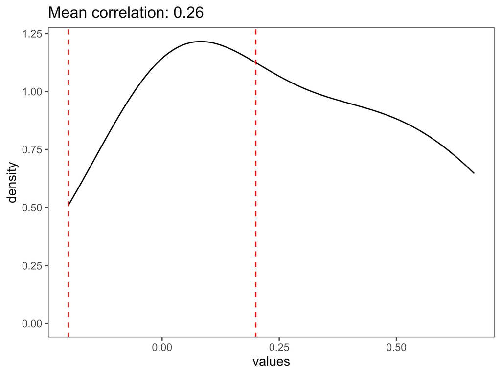

```r
test_correlation <- function(data, grouping_variables, exclusions = NULL) {
  data <- data %>%
    filter(!predictors %in% exclusions) %>%
    group_by(all_of(grouping_variables), r, k) %>%
    summarize(
      mse = weighted.mean(mse, w = n_test),
      delta_mse = weighted.mean(delta_mse, w = n_test),
      additional_variance = weighted.mean(additional_variance, w = n_test),
      n_train = sum(n_train),
      n_test = sum(n_test),
      .groups = "drop"
    ) %>%
    unite("interaction_column", all_of(grouping_variables), sep = "_") %>%
    mutate(n = (r - 1) * 10 + k) %>%
    select(n, interaction_column, delta_mse) %>%
    pivot_wider(names_from = interaction_column, values_from = delta_mse) %>%
    select(-n)

  correlation_df <- as.data.frame(cor(data, use = "pairwise.complete.obs"))

  eps = 0.2

  upper_indices <- which(upper.tri(correlation_df), arr.ind = TRUE)

  df_long <- tibble(
    row = rownames(correlation_df)[upper_indices[, 1]],
    col = colnames(correlation_df)[upper_indices[, 2]],
    values = correlation_df[upper_indices]
  )

  p <- ggplot(df_long, aes(values)) +
      geom_density(alpha = 0.15) +
      geom_vline(
        xintercept = c(-eps, eps),
        colour = "red",
        linetype = "dashed"
      ) + theme_few() + labs(title =  paste0("Mean correlation: ", round(
        mean(correlation_df[upper.tri(correlation_df)], na.rm = TRUE), 2
      )))

  return(p)
}

test_correlation(df_results_bioage,
                 grouping_variables = "predictors",
                 exclusions = "age")
```

```r
test_correlation(
  df_results_bioage,
  grouping_variables = c("age_group", "predictors"),
  exclusions = "age"
)
```

[figure not shown]

```r
if (isFALSE(params$telolength)) {
test_correlation(
  df_results_biomarkers,
  grouping_variables = "predictors",
  exclusions = c(
    "age",
    "age, phenoage",
    "age, crp, hba1c, albumin_gL",
    "age, crp, hba1c, albumin_gL, phenoage"
  )
)

test_correlation(
  df_results_biomarkers,
  grouping_variables = c("age_group", "predictors"),
  exclusions = c(
    "age",
    "age, phenoage",
    "age, crp, hba1c, albumin_gL",
    "age, crp, hba1c, albumin_gL, phenoage"
  )
)

test_correlation(
  df_results_confounders,
  grouping_variables = "predictors",
  exclusions = c(
    "full"
  )
)

test_correlation(
  df_results_confounders,
  grouping_variables = c("age_group", "predictors"),
  exclusions = c(
    "full"
  )
)
}
```

### 5.2.2 Calculate p-values

Calculate t-statistic according to nadeau bengio, which is`t = m/(√(variance(1/n + n2/n1)))`. m is the difference between the sample mean and hypothesized population mean. In this case, we’ve normalized it to age so the null hypothesis (the hypothesized population mean) is 0, i.e., there is no difference from age only. The variance we already calculated. n is equivalent to the number of folds times the number of repeats. n2 is the number of testing/validation data and n1 the number of training data. We then calculate degrees of freedom by taking n - 1. Then we use pt (which automatically calculates the critical value) using a one-tailed t-test of the upper tail. This is because we’re not interested in whether an age + bioage model is different from age-only. We only want to know if its better. We then adjust p values with Hommel or Holm error correction.

First, the question is, ‘Does this bioage/biomarker add predictive value for hearing loss in the population while controlling for chronological age?’, which we test with the overall comparisons. Only if it’s significantly different do we look at per age-group tests, also to control power. Another option is to ask ‘Might bioage/biomarker only matter for specific age ranges, even if it doesn’t have an overall predictive effect?’, in which case we could consider doing pairwise on all, but we’d lose a lot of power and would have to use FDR and accept a 5% false discovery rate to salvage it.

The CorrectR library has an implementation of the Nadeau-Bengio corrected t-test (with support for repeated k-fold validations), but this makes the false assumption that fold sizes are always equal, so there’s a small error in calculation of the sample mean and variance. The sample mean and variance should be weighted by fold size. This gets relevant for age-group delta MSEs, because for the 50-60 age group, some folds have a test size of 99 and others of 98. That means that some folds weigh 1% more than another. Not correcting for that could make the difference between significant or not signficant.

```r
nb_corrected_repeated_t_test <- function(summary_data,
                                         exceptions = NULL,
                                         exception_include_exclude,
                                         adjust_method) {
  if (exception_include_exclude == "include") {
    summary_data <- summary_data %>%
      filter(predictors %in% exceptions)
  } else {
    summary_data <- summary_data %>%
      filter(!predictors %in% exceptions)
  }

  summary_data <- summary_data %>%
    mutate(
      t = mean_delta_mse / (sqrt(
        s2_delta_mse * (1 / n + sum_n_test / sum_n_train)
      )),
      df = n - 1,
      p = pt(t, df = df, lower.tail = FALSE),
      p_adj = p.adjust(p, method = adjust_method),
      signif = case_when(
        p_adj <= 0.001 ~ "***",
        p_adj <= 0.01 ~ "**",
        p_adj <= 0.05 ~ "*",
        TRUE ~ "ns"
      )
    ) %>%
    select(-t, -df, -p, -s2_delta_mse, -sum_n_test, -sum_n_train, -n)

  return(summary_data)
}

pwc_bioage_overall <- nb_corrected_repeated_t_test(
  df_summary_bioage_overall,
  exceptions = "age",
  exception_include_exclude = "exclude",
  adjust_method = "holm"
)

pwc_bioage <- nb_corrected_repeated_t_test(
  df_summary_bioage,
  exceptions = "age, phenoage",
  exception_include_exclude = "include",
  adjust_method = "holm"
)

if (isFALSE(params$telolength)) {
pwc_biomarkers_overall <- nb_corrected_repeated_t_test(
  df_summary_biomarkers_overall,
  exceptions = c(
    "age",
    "age, phenoage",
    "age, crp, hba1c, albumin_gL",
    "age, crp, hba1c, albumin_gL, phenoage"
  ),
  exception_include_exclude = "exclude",
  adjust_method = "holm"
)  %>%
  arrange(p_adj)

pwc_biomarkers <- nb_corrected_repeated_t_test(
  df_summary_biomarkers,
  exceptions = c("age",
    "age, phenoage",
    "age, crp, hba1c, albumin_gL",
    "age, crp, hba1c, albumin_gL, phenoage"),
  exception_include_exclude = "exclude",
  adjust_method = "holm"
)

pwc_confounders_overall <- nb_corrected_repeated_t_test(
  df_summary_confounders_overall,
  exceptions = c(
    "full"
  ),
  exception_include_exclude = "exclude",
  adjust_method = "holm"
)  %>%
  arrange(p_adj)

pwc_confounders <- nb_corrected_repeated_t_test(
  df_summary_confounders,
  exceptions = c("full", "full_with_phenoage"),
  exception_include_exclude = "exclude",
  adjust_method = "holm"
)
}

pwc_bioage_overall %>% kable("html", caption = "Overall Bioage Pairwise Comparisons") %>%
  kable_styling(
    bootstrap_options = c("striped", "hover"),
    full_width = FALSE,
    position = "left",
    font_size = 12,
    fixed_thead = TRUE
  ) %>%
  scroll_box(width = "100%", height = "400px")
```

Overall Bioage Pairwise Comparisons

| predictors | mean_mse | mean_delta_mse | mean_additional_variance | ci_low_mse | ci_high_mse | ci_low_delta_mse | ci_high_delta_mse | ci_low_additional_variance | ci_high_additional_variance | n_predictions | mean_n_train | mean_n_test | r2 | rmse | delta_rmse | p_adj | signif |
| --- | --- | --- | --- | --- | --- | --- | --- | --- | --- | --- | --- | --- | --- | --- | --- | --- | --- |
| age, phenoage | 170.4259 | 1.0419142 | 0.2101892 | 155.2006 | 185.6512 | -0.5173112 | 2.6011397 | -0.7369711 | 1.157350 | 23340 | 2100.6 | 233.4 | 0.5038190 | 13.05473 | 0.0398448 | 0.2818838 | ns |
| age, kdm | 170.1852 | 1.2826336 | 0.6275134 | 155.1582 | 185.2122 | -0.0821761 | 2.6474433 | -0.2913832 | 1.546410 | 23340 | 2100.6 | 233.4 | 0.5045198 | 13.04551 | 0.0490677 | 0.1303584 | ns |
| age, hd_log | 171.6508 | -0.1829787 | -0.0937572 | 156.4173 | 186.8843 | -0.7387287 | 0.3727713 | -0.3999663 | 0.212452 | 23340 | 2100.6 | 233.4 | 0.5002528 | 13.10156 | -0.0069850 | 1.0000000 | ns |
| age, telolength | 171.6671 | -0.1992239 | -0.1406287 | 156.3798 | 186.9544 | -0.6705565 | 0.2721086 | -0.4475075 | 0.166250 | 23340 | 2100.6 | 233.4 | 0.5002055 | 13.10218 | -0.0076049 | 1.0000000 | ns |

```r
if (isFALSE(params$telolength)) {
pwc_biomarkers_overall %>% kable("html", caption = "Overall Biomarker Pairwise Comparisons") %>%
  kable_styling(
    bootstrap_options = c("striped", "hover"),
    full_width = FALSE,
    position = "left",
    font_size = 12,
    fixed_thead = TRUE
  ) %>%
  scroll_box(width = "100%", height = "400px")

pwc_confounders_overall %>% kable("html", caption = "Overall Confounder Pairwise Comparisons") %>%
  kable_styling(
    bootstrap_options = c("striped", "hover"),
    full_width = FALSE,
    position = "left",
    font_size = 12,
    fixed_thead = TRUE
  ) %>%
  scroll_box(width = "100%", height = "400px")
}
```

### 5.2.3 Add p-values to summary dataframe

```r
import_p_values <- function(summary_data, pwc_data, per_age_group) {
  if (per_age_group) {
    grouping_variables <- c("predictors", "age_group")
  } else {
    grouping_variables <- c("predictors")
  }

  updated_summary_data <- summary_data %>%
    left_join(pwc_data %>%
                select(all_of(grouping_variables), p_adj, signif), by = c(grouping_variables)) %>%
    mutate(
      p_adj = as.character(p_adj),
      p_adj = case_when(signif == "ns" ~ "ns", is.na(p_adj) ~ "ns", TRUE ~ p_adj),
      signif = case_when(is.na(signif) ~ "ns", TRUE ~ signif)
    )

  return(updated_summary_data)
}

df_summary_bioage <- import_p_values(df_summary_bioage, pwc_bioage, per_age_group = TRUE)
df_summary_bioage_overall <- import_p_values(df_summary_bioage_overall,
                                             pwc_bioage_overall,
                                             per_age_group = FALSE)

if (isFALSE(params$telolength)) {
df_summary_biomarkers <- import_p_values(df_summary_biomarkers, pwc_biomarkers, per_age_group = TRUE)
df_summary_biomarkers_overall <- import_p_values(df_summary_biomarkers_overall,
                                                 pwc_biomarkers_overall,
                                                 per_age_group = FALSE)

df_summary_confounders <- import_p_values(df_summary_confounders, pwc_confounders, per_age_group = TRUE)
df_summary_confounders_overall <- import_p_values(df_summary_confounders_overall,
                                                 pwc_confounders_overall,
                                                 per_age_group = FALSE)
}
```

**It doesn’t matter whether we use holm or hommel, so perhaps we should use hommel.**

### 5.2.4 Add raw Ns to dataframe

```r
add_n_age_groups <- function(data, summary_data, per_age_group) {
  if (per_age_group) {
    summary_data <- summary_data %>%
      rename("n_folds_repeats" = n) %>%
      left_join(data %>% select(age_group) %>%
                  group_by(age_group) %>%
                  summarize(n = n()),
                by = "age_group")
  } else {
    summary_data <- summary_data %>%
      rename("n_folds_repeats" = n) %>%
      mutate(n = nrow(data))
  }

  return(summary_data)
}

df_summary_bioage <- add_n_age_groups(df, df_summary_bioage, per_age_group = TRUE)
df_summary_bioage_overall <- add_n_age_groups(df, df_summary_bioage_overall, per_age_group = FALSE)

if (isFALSE(params$telolength)) {
df_summary_biomarkers <- add_n_age_groups(df, df_summary_biomarkers, per_age_group = TRUE)
df_summary_biomarkers_overall <- add_n_age_groups(df, df_summary_biomarkers_overall, per_age_group = FALSE)

df_summary_confounders <- add_n_age_groups(df, df_summary_confounders, per_age_group = TRUE)
df_summary_confounders_overall <- add_n_age_groups(df, df_summary_confounders_overall, per_age_group = FALSE)
}
```

## 5.3 Confounder model comparison

```r
if (isFALSE(params$telolength)) {
anova(output_confounders$models$full, output_confounders$models$full_with_phenoage)
anova(output_confounders$models$full, output_confounders$models$no_gender)
anova(output_confounders$models$full, output_confounders$models$no_smoking)
anova(output_confounders$models$full, output_confounders$models$no_race)
anova(output_confounders$models$full, output_confounders$models$no_education)
anova(output_confounders$models$full, output_confounders$models$`no_gender, race`)
}
```

# 6 Visualization

## 6.1 Descriptive Tables

### 6.1.1 Format table

Round R² and delta RMSE, rename variables, set p values to bold and to ” < 0.001” when very small.

```r
format_table <- function(summary_data, per_age_group) {
  if (per_age_group) {
    table <- summary_data %>%
      mutate(r2 = round(r2, 3),
             delta_rmse = round(delta_rmse, 2)) %>%
      rename(
        "Predictors" = predictors,
        "Age" = age_group,
        "∆RMSE (vs age, dB HL)" = delta_rmse,
        "R²" = r2,
        "p (vs age)" = p_adj
      ) %>%
      mutate(
        `p (vs age)` = case_when(
          signif == "***" ~
            cell_spec("< 0.001", "html", bold = TRUE),
          suppressWarnings(!is.na(as.numeric(`p (vs age)`)) &
                             as.numeric(`p (vs age)`) < 0.05) &
            `p (vs age)` != "< 0.001" ~
            cell_spec(suppressWarnings(round(
              as.numeric(`p (vs age)`), 3
            )), "html", bold = TRUE),
          TRUE ~ `p (vs age)`
        ),
        `p (vs age)` = as.character(`p (vs age)`),
        `p (vs age)` = case_when(Predictors == "age" ~ "", TRUE ~ `p (vs age)`),
        `∆RMSE (vs age, dB HL)` = as.character(`∆RMSE (vs age, dB HL)`),
        `∆RMSE (vs age, dB HL)` = case_when(Predictors == "age" ~ "", TRUE ~ `∆RMSE (vs age, dB HL)`)
      ) %>%
      select(Predictors, Age, n, `R²`, `∆RMSE (vs age, dB HL)`, `p (vs age)`)
  } else {
    table <- summary_data %>%
      mutate(r2 = round(r2, 3),
             delta_rmse = round(delta_rmse, 2)) %>%
      rename(
        "Predictors" = predictors,
        "∆RMSE (vs age, dB HL)" = delta_rmse,
        "R²" = r2,
        "p (vs age)" = p_adj
      ) %>%
      mutate(
        `p (vs age)` = case_when(
          signif == "***" ~
            cell_spec("< 0.001", "html", bold = TRUE),
          suppressWarnings(!is.na(as.numeric(`p (vs age)`)) &
                             as.numeric(`p (vs age)`) < 0.05) &
            `p (vs age)` != "< 0.001" ~
            cell_spec(suppressWarnings(round(
              as.numeric(`p (vs age)`), 3
            )), "html", bold = TRUE),
          TRUE ~ `p (vs age)`
        ),
        `p (vs age)` = as.character(`p (vs age)`),
        `p (vs age)` = case_when(Predictors == "age" ~ "", TRUE ~ `p (vs age)`),
        `∆RMSE (vs age, dB HL)` = as.character(`∆RMSE (vs age, dB HL)`),
        `∆RMSE (vs age, dB HL)` = case_when(Predictors == "age" ~ "", TRUE ~ `∆RMSE (vs age, dB HL)`)
      ) %>%
      select(Predictors, n, `R²`, `∆RMSE (vs age, dB HL)`, `p (vs age)`)
  }
  table <- table %>%
    rename("p (vs full model)" = `p (vs age)`,
           "∆RMSE (vs full model, dB HL)" = `∆RMSE (vs age, dB HL)`,
    )

  return(table)
}

table_bioage <- format_table(df_summary_bioage, per_age_group = TRUE)
table_bioage_overall <- format_table(df_summary_bioage_overall, per_age_group = FALSE)

if (isFALSE(params$telolength)) {
  table_biomarkers <- format_table(df_summary_biomarkers, per_age_group = TRUE)
  table_biomarkers_overall <- format_table(df_summary_biomarkers_overall, per_age_group = FALSE)

  table_confounders <- format_table(df_summary_confounders, per_age_group = TRUE)
  table_confounders_overall <- format_table(df_summary_confounders_overall, per_age_group = FALSE)
}
```

### 6.1.2 Order, Filter, and Rename Tables

```r
rename_bioage_table <- function(bioage_table) {
  if (isFALSE(params$telolength)) {
    bioage_table <- bioage_table %>%
      mutate(
        Predictors = case_when(
          Predictors == "age" ~ "Age",
          Predictors == "age, hd_log" ~ "Age + HD",
          Predictors == "age, kdm" ~ "Age + KDM",
          Predictors == "age, phenoage" ~ "Age + PhenoAge"
        ),
        Predictors = factor(
          Predictors,
          levels = c("Age", "Age + HD", "Age + KDM", "Age + PhenoAge")
        )
      ) %>%
      arrange(Predictors)
  } else {
    bioage_table <- bioage_table %>%
      mutate(
        Predictors = case_when(
          Predictors == "age" ~ "Age",
          Predictors == "age, hd_log" ~ "Age + HD",
          Predictors == "age, kdm" ~ "Age + KDM",
          Predictors == "age, phenoage" ~ "Age + PhenoAge",
          Predictors == "age, telolength" ~ "Age + Telolength"
        ),
        Predictors = factor(
          Predictors,
          levels = c(
            "Age",
            "Age + HD",
            "Age + KDM",
            "Age + PhenoAge",
            "Age + Telolength"
          )
        )
      ) %>%
      arrange(Predictors)
  }

  return(bioage_table)
}

rename_biomarker_table <- function(biomarker_table) {
  biomarker_table <- biomarker_table %>%
    filter(!(
      Predictors %in% c(
      "age",
      "age, phenoage",
      "age, crp, hba1c, albumin_gL",
      "age, crp, hba1c, albumin_gL, phenoage"
      )
    )) %>% mutate(
      Predictors = case_when(
        Predictors == "age, rdw" ~ "Age + RDW",
        Predictors == "age, alp" ~ "Age + ALP",
        Predictors == "age, crp" ~ "Age + CRP",
        Predictors == "age, totchol" ~ "Age + TC",
        Predictors == "age, albumin_gL" ~ "Age + ALB",
        Predictors == "age, hba1c" ~ "Age + HbA1c",
        Predictors == "age, glucose" ~ "Age + Glc",
        Predictors == "age, sbp" ~ "Age + SBP",
        Predictors == "age, bun" ~ "Age + BUN",
        Predictors == "age, mcv" ~ "Age + MCV",
        Predictors == "age, wbc" ~ "Age + WBC",
        Predictors == "age, lymph" ~ "Age + Lymphs",
        Predictors == "age, uap" ~ "Age + UA",
        Predictors == "age, creat" ~ "Age + Creat"
      ),
      Predictors = factor(Predictors, levels = c(
      "Age + SBP",
      "Age + BUN",
      "Age + MCV",
      "Age + Lymphs",
      "Age + RDW",
      "Age + TC",
      "Age + Creat",
      "Age + UA",
      "Age + Glc",
      "Age + WBC",
      "Age + ALP",
      "Age + ALB",
      "Age + HbA1c",
      "Age + CRP"
      )
    )) %>%
    arrange(Predictors)

  return(biomarker_table)
}

rename_confounder_table <- function(confounders_table) {
  confounders_table <- confounders_table %>%
    filter(!(
      Predictors %in% c(
      "full"
      )
    )) %>% mutate(
      Predictors = case_when(
        Predictors == "full_with_phenoage" ~ "Phenoage",
        Predictors == "no_gender" ~ "Gender",
        Predictors == "no_smoking" ~ "Smoking",
        Predictors == "no_race" ~ "Race",
        Predictors == "no_education" ~ "Education",
        Predictors == "no_gender, race" ~ "Gender * Race"
      ),
      Predictors = factor(Predictors, levels = c(
      "Phenoage",
      "Gender",
      "Smoking",
      "Race",
      "Education",
      "Gender * Race"
      )
    )) %>%
    arrange(Predictors)

  return(confounders_table)
}

table_bioage <- rename_bioage_table(table_bioage)
table_bioage_overall <- rename_bioage_table(table_bioage_overall)

if (isFALSE(params$telolength)) {
table_biomarkers <- rename_biomarker_table(table_biomarkers)
table_biomarkers_overall <- rename_biomarker_table(table_biomarkers_overall)

table_confounders <- rename_confounder_table(table_confounders)
table_confounders_overall <- rename_confounder_table(table_confounders_overall)
}
```

### 6.1.3 Render table

```r
render_and_save_table <- function(table, path) {
  html_table <- table %>%
    kable(
      format = "html",
      align = c("l", "l", "r", "r", "r", "r", "r", "r", "r"),
      escape = FALSE
    ) %>%
    kable_styling(
      bootstrap_options = c("striped", "hover", "condensed"),
      full_width = FALSE,
      position = "center"
    ) %>%
    collapse_rows(columns = 1, valign = "top")

  if (isTRUE(params$save_figures)) {
  save_kable(html_table, path)
  }

  return(html_table)
}

render_and_save_table(table_bioage, path = here("Output", "Figures", params$hearing_var, "table_bioage.html"))
```

| Predictors | Age | n | R² | ∆RMSE (vs full model, dB HL) | p (vs full model) |
| --- | --- | --- | --- | --- | --- |
| Age | 20-30 | 473 | 0.659 |  |  |
|  | 30-40 | 497 | 0.428 |  |  |
|  | 40-50 | 507 | 0.240 |  |  |
|  | 50-60 | 397 | 0.400 |  |  |
|  | 60-70 | 460 | 0.602 |  |  |
| Age + HD | 20-30 | 473 | 0.660 | 0.02 | ns |
|  | 30-40 | 497 | 0.428 | 0 | ns |
|  | 40-50 | 507 | 0.237 | -0.03 | ns |
|  | 50-60 | 397 | 0.398 | -0.04 | ns |
|  | 60-70 | 460 | 0.603 | 0.01 | ns |
| Age + KDM | 20-30 | 473 | 0.659 | 0 | ns |
|  | 30-40 | 497 | 0.444 | 0.14 | ns |
|  | 40-50 | 507 | 0.244 | 0.04 | ns |
|  | 50-60 | 397 | 0.400 | 0 | ns |
|  | 60-70 | 460 | 0.606 | 0.08 | ns |
| Age + PhenoAge | 20-30 | 473 | 0.657 | -0.02 | ns |
|  | 30-40 | 497 | 0.434 | 0.05 | ns |
|  | 40-50 | 507 | 0.240 | 0 | ns |
|  | 50-60 | 397 | 0.402 | 0.02 | ns |
|  | 60-70 | 460 | 0.608 | 0.12 | ns |
| Age + Telolength | 20-30 | 473 | 0.656 | -0.04 | ns |
|  | 30-40 | 497 | 0.428 | -0.01 | ns |
|  | 40-50 | 507 | 0.239 | -0.01 | ns |
|  | 50-60 | 397 | 0.401 | 0 | ns |
|  | 60-70 | 460 | 0.602 | 0 | ns |

```r
render_and_save_table(table_bioage_overall, path = here("Output", "Figures", params$hearing_var, "table_bioage_overall.html"))
```

| Predictors | n | R² | ∆RMSE (vs full model, dB HL) | p (vs full model) |
| --- | --- | --- | --- | --- |
| Age | 2334 | 0.501 |  |  |
| Age + HD | 2334 | 0.500 | -0.01 | ns |
| Age + KDM | 2334 | 0.505 | 0.05 | ns |
| Age + PhenoAge | 2334 | 0.504 | 0.04 | ns |
| Age + Telolength | 2334 | 0.500 | -0.01 | ns |

```r
if (isFALSE(params$telolength)) {
render_and_save_table(table_biomarkers, path = here("Output", "Figures", params$hearing_var, "table_biomarkers.html")) %>%
  scroll_box(width = "100%", height = "400px")
render_and_save_table(table_biomarkers_overall, path = here("Output", "Figures", params$hearing_var, "table_biomarkers_overall.html"))

render_and_save_table(table_confounders, path = here("Output", "Figures", params$hearing_var, "table_confounders.html")) %>%
  scroll_box(width = "100%", height = "400px")
render_and_save_table(table_confounders_overall, path = here("Output", "Figures", params$hearing_var, "table_confounders_overall.html"))
}
```

## 6.2 Confounders table

### 6.2.1 Build table and recode values

```r
build_confounder_table <- function(data, y = params$hearing_var) {
  variables = c("Gender", "Smoking", "Race", "Education")

  data <- data %>%
    mutate(
      gender = dplyr::recode(gender, "1" = "Male", "2" = "Female"),
      smoking = dplyr::recode(smoking, "1" = "Smoker", "2" = "Non-smoker"),
      race = dplyr::recode(
        race,
        "1" = "Hispanic",
        "3" = "White",
        "4" = "Black",
        "5" = "Other"
      ),
      education = dplyr::recode(
        education,
        "1" = "< 9th grade",
        "2" = "9-11th grade",
        "3" = "High school",
        "4" = "Some college or AA degree",
        "5" = "College graduate or higher"
      )
    ) %>%
    rename(
      "Smoking" = smoking,
      "Gender" = gender,
      "Race" = race,
      "Education" = education
    )

bind_rows(lapply(variables, function(variable)
  data %>%
    mutate(level = .data[[variable]]) %>%
    group_by(age_group, level) %>%
    summarise(
      mean = mean(.data[[y]], na.rm = TRUE),
      sd   = sd(.data[[y]],   na.rm = TRUE),
      .groups = "drop"
    ) %>%
    mutate(variable = factor(variable, levels = c("Gender", "Smoking", "Race", "Education")), .before = 1)
))
}

if (isFALSE(params$telolength)) {
table_confounders_descriptive <- build_confounder_table(df)
}
```

### 6.2.2 Pivot table and merge mean and standard deviation

```r
if (isFALSE(params$telolength)) {
table_confounders_descriptive <- table_confounders_descriptive %>%
  mutate(stat = sprintf("%.2f (%.2f)", mean, sd)) %>%
  select(variable, level, age_group, stat) %>%
  pivot_wider(names_from = age_group, values_from = stat)
}
```

### 6.2.3 Format table

```r
if (isFALSE(params$telolength)) {
table_confounders_descriptive <- table_confounders_descriptive %>%
  group_by(variable) %>%
  mutate(variable = if_else(row_number() == 1L, variable, "")) %>%
  ungroup() %>%
  rename(
    " " = variable,
    "  " = level
  )
}
```

### 6.2.4 Save table

```r
if (isFALSE(params$telolength)) {
render_and_save_table(table_confounders_descriptive, path = here("Output", "Figures", params$hearing_var, "table_confounders_descriptives.html"))
}
```

## 6.3 Rate of aging panel

### 6.3.1 Plot Rate of Aging

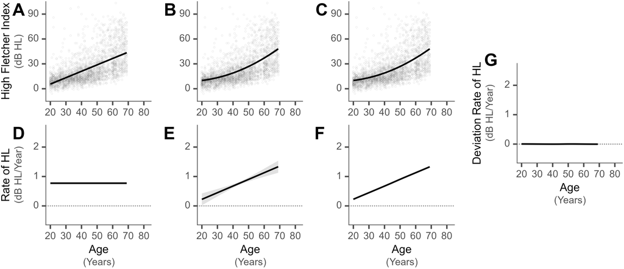

```r
p0 <- ggplot() +
  geom_point(
    data = df,
    aes(age, .data[[params$hearing_var]]),
    alpha = 0.1,
    size = 0.5,
    shape = 1,
    stroke = 0.25,
    color = "grey30"
  ) +
  geom_line(
    data = output_age_rate$predictions$linear,
    aes(x = age, y = estimate),
    linewidth = 0.6,
    alpha = 1
  ) +
      geom_ribbon(
    data = output_age_rate$predictions$linear,
    aes(
      x = age,
      ymin = ci_lower,
      ymax = ci_upper
    ),
    alpha = 0.15
  ) +
  scale_y_continuous(breaks = c(0, 30, 60, 90)) +
  scale_x_continuous(breaks = seq(20, 80, 10)) +
  coord_cartesian(ylim = c(-10, 100), xlim = c(20, 82)) +
  labs(y = "High Fletcher Index<br><span style='font-size:8pt; color:#4D4D4D'>(dB HL)</span>") +
  theme_few() +
  theme(
    axis.text.x = element_markdown("sans", size = 8),
    axis.text.y = element_markdown("sans", size = 8),
    axis.title.x = element_blank(),
    axis.title.y = element_markdown("sans", size = 9, lineheight = 1.1),
    panel.border = element_part_rect(
      colour = "grey30",
      side = "lb",
      linewidth = 0.5
    ),
    plot.margin = margin(
      t = 1,
      r = 0,
      b = 0,
      l = 1,
      unit = "pt"
    )
  )

p1 <- ggplot() +
  geom_point(
    data = df,
    aes(age, .data[[params$hearing_var]]),
    alpha = 0.1,
    size = 0.5,
    shape = 1,
    stroke = 0.25,
    color = "grey30"
  ) +
  geom_line(
    data = output_age_rate$predictions$quadratic,
    aes(x = age, y = estimate),
    linewidth = 0.6,
    alpha = 1
  ) +
      geom_ribbon(
    data = output_age_rate$predictions$quadratic,
    aes(
      x = age,
      ymin = ci_lower,
      ymax = ci_upper
    ),
    alpha = 0.15
  ) +
  scale_y_continuous(breaks = c(0, 30, 60, 90)) +
  scale_x_continuous(breaks = seq(20, 80, 10)) +
  coord_cartesian(ylim = c(-10, 100), xlim = c(20, 82)) +
  theme_few() +
  theme(
    axis.text.x = element_markdown("sans", size = 8),
    axis.text.y = element_markdown("sans", size = 8),
    axis.title.x = element_blank(),
    axis.title.y = element_blank(),
    panel.border = element_part_rect(
      colour = "grey30",
      side = "lb",
      linewidth = 0.5
    ),
    plot.margin = margin(
      t = 1,
      r = 0,
      b = 0,
      l = 1,
      unit = "pt"
    )
  )

p2 <- ggplot() +
    geom_rect(
    data = pwc_age_rate_boundaries,
    aes(
      xmin = x_min,
      xmax = x_max,
      ymin = -Inf,
      ymax = Inf
    ),
    alpha = 0.125,
    fill = "#ff0000"
  ) +
  geom_point(
    data = df,
    aes(age, .data[[params$hearing_var]]),
    alpha = 0.1,
    size = 0.5,
    shape = 1,
    stroke = 0.25,
    color = "grey30"
  ) +
  geom_ribbon(
    data = output_age_rate$predictions$smooth,
    aes(
      x = age,
      ymin = ci_lower + coef(output_age_rate$models$smooth)["(Intercept)"],
      ymax = ci_upper + coef(output_age_rate$models$smooth)["(Intercept)"]
    ),
    alpha = 0.15
  ) +
  geom_line(
    data = output_age_rate$predictions$smooth,
    aes(
      x = age,
      y = estimate + coef(output_age_rate$models$smooth)["(Intercept)"]
    ),
    linewidth = 0.6
  ) +
  scale_y_continuous(breaks = c(0, 30, 60, 90)) +
  scale_x_continuous(breaks = seq(20, 80, 10)) +
  coord_cartesian(ylim = c(-10, 100), xlim = c(20, 82)) +
  theme_few() +
  theme(
    axis.text.x = element_markdown("sans", size = 8),
    axis.text.y = element_markdown("sans", size = 8),
    axis.title.x = element_blank(),
    axis.title.y = element_blank(),
    panel.border = element_part_rect(
      colour = "grey30",
      side = "lb",
      linewidth = 0.5
    ),
    plot.margin = margin(
      t = 1,
      r = 1,
      b = 0,
      l = 0,
      unit = "pt"
    )
  )

p3 <- ggplot() +
  geom_hline(
    yintercept = 0,
    linetype = "22",
    color = "grey20",
    linewidth = 0.2
  )  +
  geom_line(
    data = output_age_rate$predictions$linear_derivative,
    aes(
      x = age,
      y = derivative
    ),
    linewidth = 0.6
  ) +
    geom_ribbon(
    data = output_age_rate$predictions$linear_derivative,
    aes(
      x = age,
      ymin = ci_lower,
      ymax = ci_upper
    ),
    alpha = 0.15
  ) +
  scale_y_continuous(breaks = c(0, 1, 2)) +
  scale_x_continuous(breaks = seq(20, 80, 10)) +
  coord_cartesian(ylim = c(-0.5, 2.6), xlim = c(20, 82)) +
  labs(x = "Age<br><span style='font-size:8pt; color:#4D4D4D'>(Years)</span>", y = "Rate of HL<br><span style='font-size:8pt; color:#4D4D4D'>(dB HL/Year)</span>") +
  theme_few() +
theme(
    axis.text.x = element_markdown("sans", size = 8),
    axis.text.y = element_markdown("sans", size = 8),
    axis.title.x = element_markdown("sans", size = 9, lineheight = 1.1),
    axis.title.y = element_markdown("sans", size = 9, lineheight = 1.1),
    panel.border = element_part_rect(
      colour = "grey30",
      side = "lb",
      linewidth = 0.5
    ),
    plot.margin = margin(
      t = 0,
      r = 0,
      b = 0,
      l = 1,
      unit = "pt"
    )
  )

p4 <- ggplot() +
  geom_hline(
    yintercept = 0,
    linetype = "22",
    color = "grey20",
    linewidth = 0.2
  )  +
  geom_line(
    data = output_age_rate$predictions$quadratic_derivative,
    aes(
      x = age,
      y = derivative
    ),
    linewidth = 0.6
  ) +
    geom_ribbon(
    data = output_age_rate$predictions$quadratic_derivative,
    aes(
      x = age,
      ymin = ci_lower,
      ymax = ci_upper
    ),
    alpha = 0.15
  ) +
  scale_y_continuous(breaks = c(0, 1, 2)) +
  scale_x_continuous(breaks = seq(20, 80, 10)) +
  coord_cartesian(ylim = c(-0.5, 2.6), xlim = c(20, 82)) +
  labs(x = "Age<br><span style='font-size:8pt; color:#4D4D4D'>(Years)</span>", y = "Rate of HL<br><span style='font-size:8pt; color:#4D4D4D'>(dB HL/Year)</span>") +
  theme_few() +
theme(
    axis.text.x = element_markdown("sans", size = 8),
    axis.text.y = element_markdown("sans", size = 8),
    axis.title.x = element_markdown("sans", size = 9, lineheight = 1.1),
    axis.title.y = element_blank(),
    panel.border = element_part_rect(
      colour = "grey30",
      side = "lb",
      linewidth = 0.5
    ),
    plot.margin = margin(
      t = 0,
      r = 0,
      b = 0,
      l = 1,
      unit = "pt"
    )
  )

p5 <- ggplot() +
    geom_rect(
    data = pwc_age_rate_boundaries,
    aes(
      xmin = x_min,
      xmax = x_max,
      ymin = -Inf,
      ymax = Inf
    ),
    alpha = 0.125,
    fill = "#ff0000"
  ) +
  geom_hline(
    yintercept = 0,
    linetype = "22",
    color = "grey20",
    linewidth = 0.2
  )  +
  geom_ribbon(
    data = output_age_rate$predictions$derivative_smooth,
    aes(
      x = age,
      ymin = ci_lower,
      ymax = ci_upper
    ),
    alpha = 0.15
  ) +
  geom_line(
    data = output_age_rate$predictions$derivative_smooth,
    aes(
      x = age,
      y = derivative
    ),
    linewidth = 0.6
  ) +
  scale_y_continuous(breaks = c(0, 1, 2)) +
  scale_x_continuous(breaks = seq(20, 80, 10)) +
  coord_cartesian(ylim = c(-0.5, 2.6), xlim = c(20, 82)) +
  labs(x = "Age<br><span style='font-size:8pt; color:#4D4D4D'>(Years)</span>", y = "Nonlinear Deviation Rate of HL<br><span style='font-size:8pt; color:#4D4D4D'>(dB HL/Year)</span>") +
  theme_few() +
theme(
    axis.text.x = element_markdown("sans", size = 8),
    axis.text.y = element_markdown("sans", size = 8),
    axis.title.x = element_markdown("sans", size = 9, lineheight = 1.1),
    axis.title.y = element_blank(),
    panel.border = element_part_rect(
      colour = "grey30",
      side = "lb",
      linewidth = 0.5
    ),
    plot.margin = margin(
      t = 0,
      r = 1,
      b = 0,
      l = 0,
      unit = "pt"
    )
  )

p6 <- ggplot() +
    geom_rect(
    data = pwc_age_rate_boundaries,
    aes(
      xmin = x_min,
      xmax = x_max,
      ymin = -Inf,
      ymax = Inf
    ),
    alpha = 0.125,
    fill = "#ff0000"
  ) +
  geom_hline(
    yintercept = 0,
    linetype = "22",
    color = "grey20",
    linewidth = 0.2
  )  +
  geom_ribbon(
    data = output_age_rate$predictions$derivative_smooth,
    aes(
      x = age,
      ymin = ci_lower_adj,
      ymax = ci_upper_adj
    ),
    alpha = 0.15
  ) +
  geom_line(
    data = output_age_rate$predictions$derivative_smooth,
    aes(
      x = age,
      y = derivative_adj
    ),
    linewidth = 0.6
  ) +
  scale_y_continuous(breaks = c(0, 1, 2)) +
  scale_x_continuous(breaks = seq(20, 80, 10)) +
  coord_cartesian(ylim = c(-0.5, 2.6), xlim = c(20, 82)) +
  labs(x = "Age<br><span style='font-size:8pt; color:#4D4D4D'>(Years)</span>", y = "Deviation Rate of HL<br><span style='font-size:8pt; color:#4D4D4D'>(dB HL/Year)</span>") +
  theme_few() +
theme(
    axis.text.x = element_markdown("sans", size = 8),
    axis.text.y = element_markdown("sans", size = 8),
    axis.title.x = element_markdown("sans", size = 9, lineheight = 1.1),
    axis.title.y = element_markdown("sans", size = 9, lineheight = 1.1),
    panel.border = element_part_rect(
      colour = "grey30",
      side = "lb",
      linewidth = 0.5
    ),
    plot.margin = margin(
      t = 0,
      r = 0,
      b = 1,
      l = 0,
      unit = "pt"
    )
  )

p <- align_plots(p0, p1, p2, p3, p4, p5, p6, align = 'hv')

p <- plot_grid(
  plot_grid(
    plot_grid(p[[1]], NULL, p[[2]], NULL, p[[3]],
      labels = c("A", "", "B", "", "C"),
      nrow = 1, rel_widths = c(1, -0.01, 1, -0.01, 1),
      label_x = 0.04, label_y = 1.02
    ),
    NULL,
    plot_grid(p[[4]], NULL, p[[5]], NULL, p[[6]],
      labels = c("D", "", "E", "", "F"),
      nrow = 1, rel_widths = c(1, -0.01, 1, -0.01, 1),
      label_x = 0.04, label_y = 1.02
    ),
    ncol = 1, rel_heights = c(1, -0.15, 1)
  ),
  NULL,
  plot_grid(
    NULL,
    p[[7]],
    NULL,
    ncol = 1,
    rel_heights = c(0.23, 0.54, 0.23),
    labels = c("", "G", ""),
    label_x = 0.04,
    label_y = 1.1
  ),
  ncol = 3,
  rel_widths = c(3, 0.1, 1.005)
)

sameplot(
  p,
  file = here("Output", "Figures", if (isTRUE(params$telolength)) paste0(params$hearing_var, "_telolength") else params$hearing_var, "age_rate_panel.png"),
  width = params$double_column,
  height = 3,
  res = 600,
  save = params$save_figures
)
```

## 6.4 Bioage panel

### 6.4.1 Plot Delta mse

[figure not shown]

```r
p <- df_summary_bioage %>%
  ggplot(aes(x = age_group, y = mean_delta_mse))  +
  geom_hline(
    yintercept = 0,
    linetype = "22",
    color = "grey20",
    linewidth = 0.2
  )  +
  geom_ribbon(
    aes(
      fill = predictors,
      group = predictors,
      ymin = ci_low_delta_mse,
      ymax = ci_high_delta_mse
    ),
    alpha = 0.15,
    show.legend = FALSE
  ) +
  geom_line(
    aes(color = predictors, group = predictors),
    linewidth = 0.7,
    alpha = 0.75,
    show.legend = TRUE
  ) +
  geom_point(
    aes(color = predictors),
    size = 1.25,
    alpha = 1,
    show.legend = TRUE
  ) +
  scale_color_manual(values = if (isTRUE(params$telolength)) {
    c(
      "age" = "#000000",
      "age, hd_log" = "#256DAB",
      "age, kdm" = "#059748",
      "age, phenoage" = "#CB2027",
      "age, telolength" = "#7B3A96"
    )
  } else {
    c(
      "age" = "#000000",
      "age, hd_log" = "#256DAB",
      "age, kdm" = "#059748",
      "age, phenoage" = "#CB2027"
    )
  }, labels = if (isTRUE(params$telolength)) {
    c("Age", "Age + HD", "Age + KDM", "Age + PhenoAge", "Age + Telolength")
  } else {
    c("Age", "Age + HD", "Age + KDM", "Age + PhenoAge")
  }) +
  scale_fill_manual(values = if (isTRUE(params$telolength)) {
    c(
      "age" = "#8C8C8C",
      "age, hd_log" = "#88BDE6",
      "age, kdm" = "#90CD97",
      "age, phenoage" = "#F07E6E",
      "age, telolength" = "#B276B2"
    )
  } else {
    c(
      "age" = "#8C8C8C",
      "age, hd_log" = "#88BDE6",
      "age, kdm" = "#90CD97",
      "age, phenoage" = "#F07E6E"
    )
  }, labels = if (isTRUE(params$telolength)) {
    c("Age", "Age + HD", "Age + KDM", "Age + PhenoAge", "Age + Telolength")
  } else {
    c("Age", "Age + HD", "Age + KDM", "Age + PhenoAge")
  }) +
  guides(
    colour = guide_legend(
      override.aes = list(size = 1.25),
      keywidth = unit(0.3, "cm"),
      keyheight = unit(0.3, "cm"),
      label.theme = element_markdown(
        "sans",
        size = 9,
        margin = margin(l = 3, t = 1.5, unit = "pt")
      ),
    )
  ) +
  scale_y_continuous(breaks = seq(0, 8, 2)) +
  coord_cartesian(ylim = c(-1, 8.5), xlim = c(1.4, 5.6)) +
  labs(x = "Age Group<br><span style='font-size:8pt; color:#4D4D4D'>(Years)</span>", y = "Additional Predictive Capacity<br><span style='font-size:8pt; color:#4D4D4D'>(Δ MSE (dB HL)<sup>2</sup>)</span>") +
  theme_few() +
  theme(
    axis.text.x = element_markdown("sans", size = 8),
    axis.text.y = element_markdown("sans", size = 8),
    axis.title.x = element_markdown("sans", size = 9, lineheight = 1.1),
    axis.title.y = element_markdown("sans", size = 9, lineheight = 1.1),
    legend.title              = element_blank(),
    legend.background         = element_rect(fill = "transparent", color = NA),
    legend.box.background     = element_rect(fill = "transparent", color = NA),
    legend.key                = element_rect(fill = "transparent"),
    legend.position           = "inside",
    legend.position.inside    = c(0.215, 0.82),
    legend.key.spacing.y      = unit(1, "pt"),
    panel.border = element_part_rect(
      colour = "grey30",
      side = "lb",
      linewidth = 0.5
    ),
    plot.margin = margin(
      t = 1,
      r = 1,
      b = 0,
      l = 1,
      unit = "pt"
    )
  ) + geom_text(
    data = . %>%
      filter(p_adj != "ns"),
    aes(
      x = age_group,
      y = ci_high_delta_mse + 0.25,
      label = signif,
      color = predictors
    ),
    manual = TRUE,
    size = 14 / (14 / 5)
  )

sameplot(
  p,
  file = here(
    "Output",
    "Figures",
    if (isTRUE(params$telolength))
      paste0(params$hearing_var, "_telolength")
    else
      params$hearing_var,
    "bioage_panel.png"
  ),
  width = params$single_column,
  height = 2.15,
  res = 600,
  save = params$save_figures
)
```

## 6.5 Supplemental Plots

### 6.5.1 Advance bioage plot

```r
df %>%
  group_by(age_group) %>%
  summarize(
    sd_phenoage_advance = sd(phenoage_advance)
  )
```

```
## # A tidytable: 5 × 2
##   age_group sd_phenoage_advance
##   <chr>                   <dbl>
## 1 20-30                    3.70
## 2 30-40                    3.96
## 3 40-50                    4.48
## 4 50-60                    4.29
## 5 60-70                    4.64
```

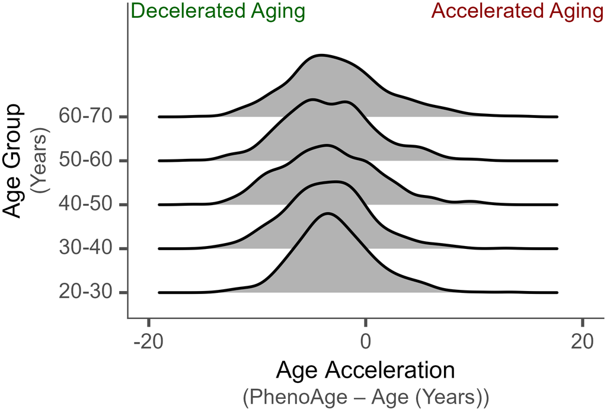

```r
p <- df %>%
  ggplot(aes(x = age, y = phenoage_advance)) +
    ggridges::geom_density_ridges(aes(x = phenoage_advance, y = age_group))+
  guides(
    colour = guide_legend(
      override.aes = list(size = 1.25),
      keywidth = unit(0.3, "cm"),
      keyheight = unit(0.3, "cm"),
      label.theme = element_markdown(
        "sans",
        size = 9,
        margin = margin(l = 3, t = 1.5, unit = "pt")
      ),
    )
  ) +
  scale_x_continuous(breaks = seq(-20, 20, 20)) +
  coord_cartesian(xlim = c(-20, 20), ylim = c(1, 7)) +
  labs(x = "Age Acceleration<br><span style='font-size:8pt; color:#4D4D4D'>(PhenoAge – Age (Years))</span>", y = "Age Group<br><span style='font-size:8pt; color:#4D4D4D'>(Years)</span>") +
  theme_few() +
  theme(
    axis.text.x = element_markdown("sans", size = 8),
    axis.text.y = element_markdown("sans", size = 8),
    axis.title.x = element_markdown("sans", size = 9, lineheight = 1.1),
    axis.title.y = element_markdown("sans", size = 9, lineheight = 1.1),
    legend.title              = element_blank(),
    legend.background         = element_rect(fill = "transparent", color = NA),
    legend.box.background     = element_rect(fill = "transparent", color = NA),
    legend.key                = element_rect(fill = "transparent"),
    legend.position           = "inside",
    legend.position.inside    = c(0.215, 0.82),
    legend.key.spacing.y      = unit(1, "pt"),
    panel.border = element_part_rect(
      colour = "grey30",
      side = "lb",
      linewidth = 0.5
    ),
    plot.margin = margin(
      t = 1,
      r = 1,
      b = 0,
      l = 1,
      unit = "pt"
    )
  ) +
  annotate(
  "text",
  x = Inf,
  y = Inf,
  label = "Decelerated Aging",
  hjust = 2.7,
  vjust = 1,
  size = 8 / (14 / 5),
  color = "darkgreen"
) +
  annotate(
  "text",
  x = Inf,
  y = Inf,
  label = "Accelerated Aging",
  hjust = 1,
  vjust = 1,
  size = 8 / (14 / 5),
  color = "darkred"
)

sameplot(
  p,
  file = here(
    "Output",
    "Figures",
    if (isTRUE(params$telolength))
      paste0(params$hearing_var, "_telolength")
    else
      params$hearing_var,
    "Extras",
    "age_acceleration.png"
  ),
  width = params$single_column,
  height = 2.15,
  res = 600,
  save = params$save_figures
)
```

### 6.5.2 Biomarkers supplemental plots

```r
if (isFALSE(params$telolength)) {
p <- df_summary_biomarkers_overall %>%
  filter(!(
    predictors %in% c(
    "age",
    "age, phenoage",
    "age, crp, hba1c, albumin_gL",
    "age, crp, hba1c, albumin_gL, phenoage"
    )
  )) %>% mutate(predictors = factor(
    predictors,
    levels = c(
      "age, sbp",
      "age, bun",
      "age, mcv",
      "age, lymph",
      "age, rdw",
      "age, totchol",
      "age, creat",
      "age, uap",
      "age, glucose",
      "age, wbc",
      "age, alp",
      "age, albumin_gL",
      "age, hba1c",
      "age, crp"
    ),
    labels = c(
      "SBP",
      "BUN",
      "MCV",
      "Lymphs",
      "RDW",
      "TC",
      "Creat",
      "UA",
      "Glc",
      "WBC",
      "ALP",
      "ALB",
      "HbA1c",
      "CRP"
    )
  )) %>%
  ggplot(aes(x = predictors, y = mean_delta_mse)) +
  geom_point(
    aes(color = predictors, fill = predictors),
    size = 2.25,
    position = position_dodge(0.8),
    alpha = 1,
    show.legend = FALSE
  ) +
  geom_linerange(
    aes(color = predictors, ymin = ci_low_delta_mse, ymax = ci_high_delta_mse),
    position = position_dodge(0.8),
    lineend = "round",
    linewidth = 0.75,
    show.legend = FALSE
  ) +
  labs(y = "Additional Predictive Capacity<br><span style='font-size:8pt; color:#4D4D4D'>(Δ MSE (dB HL)<sup>2</sup>)</span>") +
  scale_y_continuous(breaks = seq(0, 2, 1)) +
  coord_cartesian(ylim = c(-0.25, 1.5)) +
  theme_few() +
  theme(
    panel.grid.major.y = element_line(color = "grey95", linewidth = 0.25),
    axis.text.x = element_markdown("sans", size = 8, angle = 45, hjust = 1, vjust = 1),
    axis.text.y = element_markdown("sans", size = 8),
    axis.title.x = element_blank(),
    axis.title.y = element_markdown("sans", size = 9, lineheight = 1.1),
    legend.title              = element_blank(),
    legend.background         = element_rect(fill = "transparent", color = NA),
    legend.box.background     = element_rect(fill = "transparent", color = NA),
    legend.key                = element_rect(fill = "transparent"),
    legend.position           = "inside",
    legend.position.inside    = c(0.345, 0.91),
    legend.key.spacing.y      = unit(1, "pt"),
    strip.text.x              = element_markdown("sans", size = 9, lineheight = 1.1),
    panel.border = element_part_rect(
      colour = "grey30",
      side = "lb",
      linewidth = 0.5
    ),
    plot.margin = margin(
      t = 1,
      r = 1,
      b = 0,
      l = 0,
      unit = "pt"
    )
  )  + geom_text(
    data = . %>%
      filter(p_adj != "ns"),
    aes(
      x = predictors,
      y = ci_high_delta_mse + 0.25,
      label = signif,
      color = predictors
    ),
    manual = TRUE,
    size = 14 / (14 / 5),
    show.legend = FALSE
  )

sameplot(
   p,
  file = here("Output", "Figures", params$hearing_var, "biomarkers_panel.png"),
  width = params$single_column,
  height = 2.15,
  res = 600,
  save = params$save_figures
)
}
```

## 6.6 Additional Plots

### 6.6.1 Simplified Rate of Aging

```r
if (isFALSE(params$telolength)) {
p0 <- ggplot() +
  geom_point(
    data = df,
    aes(age, .data[[params$hearing_var]]),
    alpha = 0.1,
    size = 0.5,
    shape = 1,
    stroke = 0.25,
    color = "grey30"
  ) +
  geom_line(
    data = output_age_rate$predictions$linear,
    aes(x = age, y = estimate),
    linewidth = 0.6,
    alpha = 1
  ) +
      geom_ribbon(
    data = output_age_rate$predictions$linear,
    aes(
      x = age,
      ymin = ci_lower,
      ymax = ci_upper
    ),
    alpha = 0.15
  ) +
  scale_y_continuous(breaks = c(0, 30, 60, 90)) +
  scale_x_continuous(breaks = seq(20, 80, 10)) +
  coord_cartesian(ylim = c(-10, 100), xlim = c(20, 82)) +
  labs(y = "High Fletcher Index<br><span style='font-size:8pt; color:#4D4D4D'>(dB HL)</span>") +
  theme_few() +
  theme(
    axis.text.x = element_markdown("sans", size = 8),
    axis.text.y = element_markdown("sans", size = 8),
    axis.title.x = element_blank(),
    axis.title.y = element_markdown("sans", size = 9, lineheight = 1.1),
    panel.border = element_part_rect(
      colour = "grey30",
      side = "lb",
      linewidth = 0.5
    ),
    plot.margin = margin(
      t = 1,
      r = 0,
      b = 0,
      l = 1,
      unit = "pt"
    )
  )

p1 <- ggplot() +
  geom_point(
    data = df,
    aes(age, .data[[params$hearing_var]]),
    alpha = 0.1,
    size = 0.5,
    shape = 1,
    stroke = 0.25,
    color = "grey30"
  ) +
  geom_line(
    data = output_age_rate$predictions$quadratic,
    aes(x = age, y = estimate),
    linewidth = 0.6,
    alpha = 1
  ) +
      geom_ribbon(
    data = output_age_rate$predictions$quadratic,
    aes(
      x = age,
      ymin = ci_lower,
      ymax = ci_upper
    ),
    alpha = 0.15
  ) +
  scale_y_continuous(breaks = c(0, 30, 60, 90)) +
  scale_x_continuous(breaks = seq(20, 80, 10)) +
  coord_cartesian(ylim = c(-10, 100), xlim = c(20, 82)) +
  theme_few() +
  theme(
    axis.text.x = element_markdown("sans", size = 8),
    axis.text.y = element_markdown("sans", size = 8),
    axis.title.x = element_blank(),
    axis.title.y = element_blank(),
    panel.border = element_part_rect(
      colour = "grey30",
      side = "lb",
      linewidth = 0.5
    ),
    plot.margin = margin(
      t = 1,
      r = 0,
      b = 0,
      l = 1,
      unit = "pt"
    )
  )

p2 <- ggplot() +
    geom_rect(
    data = pwc_age_rate_boundaries,
    aes(
      xmin = x_min,
      xmax = x_max,
      ymin = -Inf,
      ymax = Inf
    ),
    alpha = 0.125,
    fill = "#ff0000"
  ) +
  geom_point(
    data = df,
    aes(age, .data[[params$hearing_var]]),
    alpha = 0.1,
    size = 0.5,
    shape = 1,
    stroke = 0.25,
    color = "grey30"
  ) +
  geom_ribbon(
    data = output_age_rate$predictions$smooth,
    aes(
      x = age,
      ymin = ci_lower + coef(output_age_rate$models$smooth)["(Intercept)"],
      ymax = ci_upper + coef(output_age_rate$models$smooth)["(Intercept)"]
    ),
    alpha = 0.15
  ) +
  geom_line(
    data = output_age_rate$predictions$smooth,
    aes(
      x = age,
      y = estimate + coef(output_age_rate$models$smooth)["(Intercept)"]
    ),
    linewidth = 0.6
  ) +
  scale_y_continuous(breaks = c(0, 30, 60, 90)) +
  scale_x_continuous(breaks = seq(20, 80, 10)) +
  coord_cartesian(ylim = c(-10, 100), xlim = c(20, 82)) +
  theme_few() +
  theme(
    axis.text.x = element_markdown("sans", size = 8),
    axis.text.y = element_markdown("sans", size = 8),
    axis.title.x = element_blank(),
    axis.title.y = element_blank(),
    panel.border = element_part_rect(
      colour = "grey30",
      side = "lb",
      linewidth = 0.5
    ),
    plot.margin = margin(
      t = 1,
      r = 1,
      b = 0,
      l = 0,
      unit = "pt"
    )
  )

p3 <- ggplot() +
  geom_hline(
    yintercept = 0,
    linetype = "22",
    color = "grey20",
    linewidth = 0.2
  )  +
  geom_line(
    data = output_age_rate$predictions$linear_derivative,
    aes(
      x = age,
      y = derivative
    ),
    linewidth = 0.6
  ) +
    geom_ribbon(
    data = output_age_rate$predictions$linear_derivative,
    aes(
      x = age,
      ymin = ci_lower,
      ymax = ci_upper
    ),
    alpha = 0.15
  ) +
  scale_y_continuous(breaks = c(0, 1, 2)) +
  scale_x_continuous(breaks = seq(20, 80, 10)) +
  coord_cartesian(ylim = c(-0.5, 2.6), xlim = c(20, 82)) +
  labs(x = "Age<br><span style='font-size:8pt; color:#4D4D4D'>(Years)</span>", y = "Rate of HL<br><span style='font-size:8pt; color:#4D4D4D'>(dB HL/Year)</span>") +
  theme_few() +
theme(
    axis.text.x = element_markdown("sans", size = 8),
    axis.text.y = element_markdown("sans", size = 8),
    axis.title.x = element_markdown("sans", size = 9, lineheight = 1.1),
    axis.title.y = element_markdown("sans", size = 9, lineheight = 1.1),
    panel.border = element_part_rect(
      colour = "grey30",
      side = "lb",
      linewidth = 0.5
    ),
    plot.margin = margin(
      t = 0,
      r = 0,
      b = 0,
      l = 1,
      unit = "pt"
    )
  )

p4 <- ggplot() +
  geom_hline(
    yintercept = 0,
    linetype = "22",
    color = "grey20",
    linewidth = 0.2
  )  +
  geom_line(
    data = output_age_rate$predictions$quadratic_derivative,
    aes(
      x = age,
      y = derivative
    ),
    linewidth = 0.6
  ) +
    geom_ribbon(
    data = output_age_rate$predictions$quadratic_derivative,
    aes(
      x = age,
      ymin = ci_lower,
      ymax = ci_upper
    ),
    alpha = 0.15
  ) +
  scale_y_continuous(breaks = c(0, 1, 2)) +
  scale_x_continuous(breaks = seq(20, 80, 10)) +
  coord_cartesian(ylim = c(-0.5, 2.6), xlim = c(20, 82)) +
  labs(x = "Age<br><span style='font-size:8pt; color:#4D4D4D'>(Years)</span>", y = "Rate of HL<br><span style='font-size:8pt; color:#4D4D4D'>(dB HL/Year)</span>") +
  theme_few() +
theme(
    axis.text.x = element_markdown("sans", size = 8),
    axis.text.y = element_markdown("sans", size = 8),
    axis.title.x = element_markdown("sans", size = 9, lineheight = 1.1),
    axis.title.y = element_blank(),
    panel.border = element_part_rect(
      colour = "grey30",
      side = "lb",
      linewidth = 0.5
    ),
    plot.margin = margin(
      t = 0,
      r = 0,
      b = 0,
      l = 1,
      unit = "pt"
    )
  )

p5 <- ggplot() +
    geom_rect(
    data = pwc_age_rate_boundaries,
    aes(
      xmin = x_min,
      xmax = x_max,
      ymin = -Inf,
      ymax = Inf
    ),
    alpha = 0.125,
    fill = "#ff0000"
  ) +
  geom_hline(
    yintercept = 0,
    linetype = "22",
    color = "grey20",
    linewidth = 0.2
  )  +
  geom_ribbon(
    data = output_age_rate$predictions$derivative_smooth,
    aes(
      x = age,
      ymin = ci_lower,
      ymax = ci_upper
    ),
    alpha = 0.15
  ) +
  geom_line(
    data = output_age_rate$predictions$derivative_smooth,
    aes(
      x = age,
      y = derivative
    ),
    linewidth = 0.6
  ) +
  scale_y_continuous(breaks = c(0, 1, 2)) +
  scale_x_continuous(breaks = seq(20, 80, 10)) +
  coord_cartesian(ylim = c(-0.5, 2.6), xlim = c(20, 82)) +
  labs(x = "Age<br><span style='font-size:8pt; color:#4D4D4D'>(Years)</span>", y = "Nonlinear Deviation Rate of HL<br><span style='font-size:8pt; color:#4D4D4D'>(dB HL/Year)</span>") +
  theme_few() +
theme(
    axis.text.x = element_markdown("sans", size = 8),
    axis.text.y = element_markdown("sans", size = 8),
    axis.title.x = element_markdown("sans", size = 9, lineheight = 1.1),
    axis.title.y = element_blank(),
    panel.border = element_part_rect(
      colour = "grey30",
      side = "lb",
      linewidth = 0.5
    ),
    plot.margin = margin(
      t = 0,
      r = 1,
      b = 0,
      l = 0,
      unit = "pt"
    )
  )

p <- align_plots(p0, p1, p2, p3, p4, p5, align = 'hv')

p <-
  plot_grid(
    plot_grid(p[[1]], NULL, p[[2]], NULL, p[[3]],
      labels = c("A", "", "B", "", "C"),
      nrow = 1, rel_widths = c(1, -0.01, 1, -0.01, 1),
      label_x = 0.04, label_y = 1.02
    ),
    NULL,
    plot_grid(p[[4]], NULL, p[[5]], NULL, p[[6]],
      labels = c("D", "", "E", "", "F"),
      nrow = 1, rel_widths = c(1, -0.01, 1, -0.01, 1),
      label_x = 0.04, label_y = 1.02
    ),
    ncol = 1, rel_heights = c(1, -0.15, 1)
  )

sameplot(
  p,
  file = here("Output", "Figures", params$hearing_var, "Extras", "simplified_age_rate_panel.png"),
  width = params$double_column * 1.8,
  height = 3 * 1.8,
  scaling = 1.8,
  res = 600,
  save = params$save_figures
)
}
```

### 6.6.2 Blank rate of aging

```r
if (isFALSE(params$telolength)) {
p0 <- ggplot() +
  geom_point(
    data = df,
    aes(age, .data[[params$hearing_var]]),
    alpha = 0.1,
    size = 0.5,
    shape = 1,
    stroke = 0.25,
    color = "grey30"
  ) +
  scale_y_continuous(breaks = c(0, 30, 60, 90)) +
  scale_x_continuous(breaks = seq(20, 80, 10)) +
  coord_cartesian(ylim = c(-10, 100), xlim = c(20, 82)) +
  labs(y = "High Fletcher Index<br><span style='font-size:8pt; color:#4D4D4D'>(dB HL)</span>") +
  theme_few() +
  theme(
    axis.text.x = element_markdown("sans", size = 8),
    axis.text.y = element_markdown("sans", size = 8),
    axis.title.x = element_blank(),
    axis.title.y = element_markdown("sans", size = 9, lineheight = 1.1),
    panel.border = element_part_rect(
      colour = "grey30",
      side = "lb",
      linewidth = 0.5
    ),
    plot.margin = margin(
      t = 1,
      r = 0,
      b = 0,
      l = 1,
      unit = "pt"
    )
  )

p1 <- ggplot() +
  geom_point(
    data = df,
    aes(age, .data[[params$hearing_var]]),
    alpha = 0.1,
    size = 0.5,
    shape = 1,
    stroke = 0.25,
    color = "grey30"
  ) +
  scale_y_continuous(breaks = c(0, 30, 60, 90)) +
  scale_x_continuous(breaks = seq(20, 80, 10)) +
  coord_cartesian(ylim = c(-10, 100), xlim = c(20, 82)) +
  labs(y = "High Fletcher Index<br><span style='font-size:8pt; color:#4D4D4D'>(dB HL)</span>") +
  theme_few() +
  theme(
    axis.text.x = element_markdown("sans", size = 8),
    axis.text.y = element_markdown("sans", size = 8),
    axis.title.x = element_blank(),
    axis.title.y = element_blank(),
    panel.border = element_part_rect(
      colour = "grey30",
      side = "lb",
      linewidth = 0.5
    ),
    plot.margin = margin(
      t = 1,
      r = 0,
      b = 0,
      l = 1,
      unit = "pt"
    )
  )

p2 <- ggplot() +
  geom_point(
    data = df,
    aes(age, .data[[params$hearing_var]]),
    alpha = 0.1,
    size = 0.5,
    shape = 1,
    stroke = 0.25,
    color = "grey30"
  ) +
  scale_y_continuous(breaks = c(0, 30, 60, 90)) +
  scale_x_continuous(breaks = seq(20, 80, 10)) +
  coord_cartesian(ylim = c(-10, 100), xlim = c(20, 82)) +
  labs(y = "High Fletcher Index<br><span style='font-size:8pt; color:#4D4D4D'>(dB HL)</span>") +
  theme_few() +
  theme(
    axis.text.x = element_markdown("sans", size = 8),
    axis.text.y = element_markdown("sans", size = 8),
    axis.title.x = element_blank(),
    axis.title.y = element_blank(),
    panel.border = element_part_rect(
      colour = "grey30",
      side = "lb",
      linewidth = 0.5
    ),
    plot.margin = margin(
      t = 1,
      r = 1,
      b = 0,
      l = 0,
      unit = "pt"
    )
  )

p3 <- ggplot() +
  geom_hline(
    yintercept = 0,
    linetype = "22",
    color = "grey20",
    linewidth = 0.2
  )  +
  geom_line(
    data = output_age_rate$predictions$linear_derivative,
    aes(x = age, y = derivative),
    linewidth = 0.6,
    color = "white"
  ) +
  scale_y_continuous(breaks = c(0, 1, 2)) +
  scale_x_continuous(breaks = seq(20, 80, 10)) +
  coord_cartesian(ylim = c(-0.5, 2.6), xlim = c(20, 82)) +
  labs(x = "Age<br><span style='font-size:8pt; color:#4D4D4D'>(Years)</span>", y = "Rate of HL<br><span style='font-size:8pt; color:#4D4D4D'>(dB HL/Year)</span>") +
  theme_few() +
theme(
    axis.text.x = element_markdown("sans", size = 8),
    axis.text.y = element_markdown("sans", size = 8),
    axis.title.x = element_markdown("sans", size = 9, lineheight = 1.1),
    axis.title.y = element_markdown("sans", size = 9, lineheight = 1.1),
    panel.border = element_part_rect(
      colour = "grey30",
      side = "lb",
      linewidth = 0.5
    ),
    plot.margin = margin(
      t = 0,
      r = 0,
      b = 0,
      l = 1,
      unit = "pt"
    )
  )

p4 <- ggplot() +
  geom_hline(
    yintercept = 0,
    linetype = "22",
    color = "grey20",
    linewidth = 0.2
  )  +
  geom_line(
    data = output_age_rate$predictions$linear_derivative,
    aes(x = age, y = derivative),
    linewidth = 0.6,
    color = "white"
  ) +
  scale_y_continuous(breaks = c(0, 1, 2)) +
  scale_x_continuous(breaks = seq(20, 80, 10)) +
  coord_cartesian(ylim = c(-0.5, 2.6), xlim = c(20, 82)) +
  labs(x = "Age<br><span style='font-size:8pt; color:#4D4D4D'>(Years)</span>", y = "Rate of HL<br><span style='font-size:8pt; color:#4D4D4D'>(dB HL/Year)</span>") +
  theme_few() +
theme(
    axis.text.x = element_markdown("sans", size = 8),
    axis.text.y = element_markdown("sans", size = 8),
    axis.title.x = element_markdown("sans", size = 9, lineheight = 1.1),
    axis.title.y = element_blank(),
    panel.border = element_part_rect(
      colour = "grey30",
      side = "lb",
      linewidth = 0.5
    ),
    plot.margin = margin(
      t = 0,
      r = 0,
      b = 0,
      l = 1,
      unit = "pt"
    )
  )

p5 <- ggplot() +
  geom_hline(
    yintercept = 0,
    linetype = "22",
    color = "grey20",
    linewidth = 0.2
  )  +
    geom_line(
    data = output_age_rate$predictions$linear_derivative,
    aes(x = age, y = derivative),
    linewidth = 0.6,
    color = "white"
  ) +
  scale_y_continuous(breaks = c(0, 1, 2)) +
  scale_x_continuous(breaks = seq(20, 80, 10)) +
  coord_cartesian(ylim = c(-0.5, 2.6), xlim = c(20, 82)) +
  labs(x = "Age<br><span style='font-size:8pt; color:#4D4D4D'>(Years)</span>", y = "Rate of HL<br><span style='font-size:8pt; color:#4D4D4D'>(dB HL/Year)</span>") +
  theme_few() +
theme(
    axis.text.x = element_markdown("sans", size = 8),
    axis.text.y = element_markdown("sans", size = 8),
    axis.title.x = element_markdown("sans", size = 9, lineheight = 1.1),
    axis.title.y = element_blank(),
    panel.border = element_part_rect(
      colour = "grey30",
      side = "lb",
      linewidth = 0.5
    ),
    plot.margin = margin(
      t = 0,
      r = 1,
      b = 0,
      l = 0,
      unit = "pt"
    )
  )

p <- align_plots(p0, p1, p2, p3, p4, p5, align = 'hv')

p <-
  plot_grid(
    plot_grid(p[[1]], NULL, p[[2]], NULL, p[[3]],
      labels = c("A", "", "B", "", "C"),
      nrow = 1, rel_widths = c(1, -0.01, 1, -0.01, 1),
      label_x = 0.04, label_y = 1.02
    ),
    NULL,
    plot_grid(p[[4]], NULL, p[[5]], NULL, p[[6]],
      labels = c("D", "", "E", "", "F"),
      nrow = 1, rel_widths = c(1, -0.01, 1, -0.01, 1),
      label_x = 0.04, label_y = 1.02
    ),
    ncol = 1, rel_heights = c(1, -0.15, 1)
  )

sameplot(
  p,
  file = here("Output", "Figures", params$hearing_var, "Extras", "blank_age_rate_panel.png"),
  width = params$double_column * 1.8,
  height = 3 * 1.8,
  scaling = 1.8,
  res = 600,
  save = params$save_figures
)
}
```

## 6.7 Confounders panel

### 6.7.1 Plot Delta mse confounders

```r
if (isFALSE(params$telolength)) {
p <- df_summary_confounders %>%
  ggplot(aes(x = age_group, y = mean_delta_mse))  +
  geom_hline(
    yintercept = 0,
    linetype = "22",
    color = "grey20",
    linewidth = 0.2
  )  +
  geom_ribbon(
    aes(
      fill = predictors,
      group = predictors,
      ymin = ci_low_delta_mse,
      ymax = ci_high_delta_mse
    ),
    alpha = 0.15,
    show.legend = FALSE
  ) +
  geom_line(
    aes(color = predictors, group = predictors),
    linewidth = 0.7,
    alpha = 0.75,
    show.legend = TRUE
  ) +
  geom_point(
    aes(color = predictors),
    size = 1.25,
    alpha = 1,
    show.legend = TRUE
  ) +
  scale_color_manual(
    values =
      c(
        "full" = "#000000",
        "full_with_phenoage" = "#256DAB",
        "no_education" = "#DF5C24",
        "no_gender" = "#059748",
        "no_gender, race" = "#7B3A96",
        "no_race" = "#E5126F",
        "no_smoking" = "#9D722A"
      ),
    labels = c(
      "Full",
      "Phenoage",
      "Education",
      "Gender",
      "Gender*Race",
      "Race",
      "Smoking"
    )
  ) +
    scale_fill_manual(
    values =
      c(
        "full" = "#8C8C8C",
        "full_with_phenoage" = "#88BDE6",
        "no_education" = "#FBB258",
        "no_gender" = "#90CD97",
        "no_gender, race" = "#BC99C7",
        "no_race" = "#F6AAC9",
        "no_smoking" = "#BFA554"
      ),
    labels = c(
      "Full",
      "Phenoage",
      "Education",
      "Gender",
      "Gender*Race",
      "Race",
      "Smoking"
    )
  ) +
  guides(
    colour = guide_legend(
      override.aes = list(size = 1.25),
      keywidth = unit(0.3, "cm"),
      keyheight = unit(0.3, "cm"),
      label.theme = element_markdown(
        "sans",
        size = 9,
        margin = margin(l = 3, t = 1.5, unit = "pt")
      ),
    )
  ) +
  scale_y_continuous(breaks = seq(0, 40, 5)) +
  coord_cartesian(ylim = c(-1, 40), xlim = c(1.4, 5.6)) +
  labs(x = "Age Group<br><span style='font-size:8pt; color:#4D4D4D'>(Years)</span>", y = "Additional Predictive Capacity<br><span style='font-size:8pt; color:#4D4D4D'>(Δ MSE (dB HL)<sup>2</sup>)</span>") +
  theme_few() +
  theme(
    axis.text.x = element_markdown("sans", size = 8),
    axis.text.y = element_markdown("sans", size = 8),
    axis.title.x = element_markdown("sans", size = 9, lineheight = 1.1),
    axis.title.y = element_markdown("sans", size = 9, lineheight = 1.1),
    legend.title              = element_blank(),
    legend.background         = element_rect(fill = "transparent", color = NA),
    legend.box.background     = element_rect(fill = "transparent", color = NA),
    legend.key                = element_rect(fill = "transparent"),
    legend.position           = "inside",
    legend.justification.inside    = c(0, 1),
    legend.key.spacing.y      = unit(1, "pt"),
    panel.border = element_part_rect(
      colour = "grey30",
      side = "lb",
      linewidth = 0.5
    ),
    plot.margin = margin(
      t = 1,
      r = 1,
      b = 0,
      l = 1,
      unit = "pt"
    )
  ) + geom_text(
    data = . %>%
      filter(p_adj != "ns"),
    aes(
      x = age_group,
      y = ci_high_delta_mse,
      label = signif,
      color = predictors
    ),
    manual = TRUE,
    size = 14 / (14 / 5)
  )

sameplot(
  p,
  file = here(
    "Output",
    "Figures",
    "confounder_panel.png"
  ),
  width = params$single_column,
  height = 2.15,
  res = 600,
  save = params$save_figures
)
}
```

### 6.7.2 Plot additional variance confounders

```r
if (isFALSE(params$telolength)) {
p <- df_summary_confounders %>%
  ggplot(aes(x = age_group, y = mean_additional_variance))  +
  geom_hline(
    yintercept = 0,
    linetype = "22",
    color = "grey20",
    linewidth = 0.2
  )  +
  geom_ribbon(
    aes(
      fill = predictors,
      group = predictors,
      ymin = ci_low_additional_variance,
      ymax = ci_high_additional_variance
    ),
    alpha = 0.15,
    show.legend = FALSE
  ) +
  geom_line(
    aes(color = predictors, group = predictors),
    linewidth = 0.7,
    alpha = 0.75,
    show.legend = TRUE
  ) +
  geom_point(
    aes(color = predictors),
    size = 1.25,
    alpha = 1,
    show.legend = TRUE
  ) +
  scale_color_manual(
    values =
      c(
        "full" = "#000000",
        "full_with_phenoage" = "#256DAB",
        "no_education" = "#DF5C24",
        "no_gender" = "#059748",
        "no_gender, race" = "#7B3A96",
        "no_race" = "#E5126F",
        "no_smoking" = "#9D722A"
      ),
    labels = c(
      "Full",
      "Phenoage",
      "Education",
      "Gender",
      "Gender*Race",
      "Race",
      "Smoking"
    )
  ) +
    scale_fill_manual(
    values =
      c(
        "full" = "#8C8C8C",
        "full_with_phenoage" = "#88BDE6",
        "no_education" = "#FBB258",
        "no_gender" = "#90CD97",
        "no_gender, race" = "#BC99C7",
        "no_race" = "#F6AAC9",
        "no_smoking" = "#BFA554"
      ),
    labels = c(
      "Full",
      "Phenoage",
      "Education",
      "Gender",
      "Gender*Race",
      "Race",
      "Smoking"
    )
  ) +
  guides(
    colour = guide_legend(
      override.aes = list(size = 1.25),
      keywidth = unit(0.3, "cm"),
      keyheight = unit(0.3, "cm"),
      label.theme = element_markdown(
        "sans",
        size = 9,
        margin = margin(l = 3, t = 1.5, unit = "pt")
      ),
    )
  ) +
  scale_y_continuous(breaks = seq(0, 8, 2)) +
  coord_cartesian(ylim = c(-1, 15), xlim = c(1.4, 5.6)) +
  labs(x = "Age Group<br><span style='font-size:8pt; color:#4D4D4D'>(Years)</span>", y = "Additional Predictive Capacity<br><span style='font-size:8pt; color:#4D4D4D'>(Δ % Variance Explained)</span>") +
  theme_few() +
  theme(
    axis.text.x = element_markdown("sans", size = 8),
    axis.text.y = element_markdown("sans", size = 8),
    axis.title.x = element_markdown("sans", size = 9, lineheight = 1.1),
    axis.title.y = element_markdown("sans", size = 9, lineheight = 1.1),
    legend.title              = element_blank(),
    legend.background         = element_rect(fill = "transparent", color = NA),
    legend.box.background     = element_rect(fill = "transparent", color = NA),
    legend.key                = element_rect(fill = "transparent"),
    legend.position           = "inside",
    legend.justification.inside    = c(0, 1),
    legend.key.spacing.y      = unit(1, "pt"),
    panel.border = element_part_rect(
      colour = "grey30",
      side = "lb",
      linewidth = 0.5
    ),
    plot.margin = margin(
      t = 1,
      r = 1,
      b = 0,
      l = 1,
      unit = "pt"
    )
  ) + geom_text(
    data = . %>%
      filter(p_adj != "ns"),
    aes(
      x = age_group,
      y = ci_high_additional_variance,
      label = signif,
      color = predictors
    ),
    manual = TRUE,
    size = 14 / (14 / 5)
  )

sameplot(
  p,
  file = here(
    "Output",
    "Figures",
    "confounder_panel_var.png"
  ),
  width = params$single_column,
  height = 2.15,
  res = 600,
  save = params$save_figures
)
}
```

### 6.7.3 Plot PhenoAge Only

```r
if (isFALSE(params$telolength)) {
p <- df_summary_bioage %>% filter(
  predictors %in% c("age", "age, phenoage")
) %>%
  ggplot(aes(x = age_group, y = mean_delta_mse))  +
  geom_hline(
    yintercept = 0,
    linetype = "22",
    color = "grey20",
    linewidth = 0.2
  )  +
  geom_ribbon(
    aes(
      fill = predictors,
      group = predictors,
      ymin = ci_low_delta_mse,
      ymax = ci_high_delta_mse
    ),
    alpha = 0.15,
    show.legend = FALSE
  ) +
  geom_line(
    aes(color = predictors, group = predictors),
    linewidth = 0.7,
    alpha = 0.75,
    show.legend = TRUE
  ) +
  geom_point(
    aes(color = predictors),
    size = 1.25,
    alpha = 1,
    show.legend = TRUE
  ) +
  scale_color_manual(
    values = c(
      "age" = "#000000",
      "age, phenoage" = "#CB2027"
    ),
    labels = c("Age", "Age + PhenoAge")
  ) +
  scale_fill_manual(
    values = c(
      "age" = "#8C8C8C",
      "age, phenoage" = "#F07E6E"
    ),
    labels = c("Age","Age + PhenoAge")
  ) +
  guides(
    colour = guide_legend(
      override.aes = list(size = 1.25),
      keywidth = unit(0.3, "cm"),
      keyheight = unit(0.3, "cm"),
      label.theme = element_markdown(
        "sans",
        size = 9,
        margin = margin(l = 3, t = 1.5, unit = "pt")
      ),
    )
  ) +
  scale_y_continuous(breaks = seq(0, 8, 2)) +
  coord_cartesian(ylim = c(-1, 8.5), xlim = c(1.4, 5.6)) +
  labs(x = "Age Group<br><span style='font-size:8pt; color:#4D4D4D'>(Years)</span>", y = "Additional Predictive Capacity<br><span style='font-size:8pt; color:#4D4D4D'>(Δ MSE (dB HL)<sup>2</sup>)</span>") +
  theme_few() +
  theme(
    axis.text.x = element_markdown("sans", size = 8),
    axis.text.y = element_markdown("sans", size = 8),
    axis.title.x = element_markdown("sans", size = 9, lineheight = 1.1),
    axis.title.y = element_markdown("sans", size = 9, lineheight = 1.1),
    legend.title              = element_blank(),
    legend.background         = element_rect(fill = "transparent", color = NA),
    legend.box.background     = element_rect(fill = "transparent", color = NA),
    legend.key                = element_rect(fill = "transparent"),
    legend.position           = "inside",
    legend.position.inside    = c(0.215, 0.82),
    legend.key.spacing.y      = unit(1, "pt"),
    panel.border = element_part_rect(
      colour = "grey30",
      side = "lb",
      linewidth = 0.5
    ),
    plot.margin = margin(
      t = 1,
      r = 1,
      b = 0,
      l = 1,
      unit = "pt"
    )
  ) + geom_text(
    data = . %>%
      filter(p_adj != "ns"),
    aes(
      x = age_group,
      y = ci_high_delta_mse + 0.25,
      label = signif,
      color = predictors
    ),
    manual = TRUE,
    size = 14 / (14 / 5)
  )

sameplot(
  p,
  file = here("Output", "Figures", params$hearing_var, "Extras", "phenoage_only_bioage_panel.png"),
  width = params$single_column * 1.8,
  height = 2.15 * 1.8,
  scaling = 1.8,
  res = 600,
  save = params$save_figures
)
}
```

### 6.7.4 Rate of aging gender

#### 6.7.4.1 Calculate gender GAM

```r
if (isFALSE(params$telolength)) {
gam_gender <- bam(
  as.formula(paste0(params$hearing_var, "~ s(age, k = 10) + s(gender, age, bs = 'sz', k = 10)")),
  data = df,
  method = "REML",
  family = gaussian()
)

gender_predictions <- as.data.frame(confint(
    emmeans(
      gam_gender,
      as.formula(paste("~ age + gender")),
      at = setNames(list(seq(
        min(df[["age"]]), max(df[["age"]]), by = 1
      )), "age"),
      type = "response",
      data = df
    ),
    adjust = "mvt"
  )) %>%
    rename("estimate" = emmean,
           "ci_lower" = lower.CL,
           "ci_upper" = upper.CL)

gender_predictions_der <-  data.frame(confint(
    emtrends(
      gam_gender,
      as.formula(paste("~ age + gender")),
      var = "age",
      at = setNames(list(seq(
        min(df[["age"]]), max(df[["age"]]), by = 1
      )), "age"),
      data = df
    ),
    adjust = "mvt"
  )) %>%
    rename(
      "derivative" = !!paste0("age", ".trend"),
      "ci_lower" = lower.CL,
      "ci_upper" = upper.CL
    )
}
```

#### 6.7.4.2 Plot rate of aging gender

```r
if (isFALSE(params$telolength)) {
p0 <- ggplot() +
  geom_point(
    data = df,
    aes(age, .data[[params$hearing_var]]),
    alpha = 0.1,
    size = 0.5,
    shape = 1,
    stroke = 0.25,
    color = "grey30"
  ) +
  geom_line(
    data = output_age_rate$predictions$linear,
    aes(x = age, y = estimate),
    linewidth = 0.6,
    alpha = 1
  ) +
      geom_ribbon(
    data = output_age_rate$predictions$linear,
    aes(
      x = age,
      ymin = ci_lower,
      ymax = ci_upper
    ),
    alpha = 0.15
  ) +
  scale_y_continuous(breaks = c(0, 30, 60, 90)) +
  scale_x_continuous(breaks = seq(20, 80, 10)) +
  coord_cartesian(ylim = c(-10, 100), xlim = c(20, 82)) +
  labs(y = "High Fletcher Index<br><span style='font-size:8pt; color:#4D4D4D'>(dB HL)</span>") +
  theme_few() +
  theme(
    axis.text.x = element_markdown("sans", size = 8),
    axis.text.y = element_markdown("sans", size = 8),
    axis.title.x = element_blank(),
    axis.title.y = element_markdown("sans", size = 9, lineheight = 1.1),
    panel.border = element_part_rect(
      colour = "grey30",
      side = "lb",
      linewidth = 0.5
    ),
    plot.margin = margin(
      t = 1,
      r = 0,
      b = 0,
      l = 1,
      unit = "pt"
    )
  )

p1 <- ggplot() +
  geom_point(
    data = df,
    aes(age, .data[[params$hearing_var]]),
    alpha = 0.1,
    size = 0.5,
    shape = 1,
    stroke = 0.25,
    color = "grey30"
  ) +
  geom_line(
    data = output_age_rate$predictions$quadratic,
    aes(x = age, y = estimate),
    linewidth = 0.6,
    alpha = 1
  ) +
      geom_ribbon(
    data = output_age_rate$predictions$quadratic,
    aes(
      x = age,
      ymin = ci_lower,
      ymax = ci_upper
    ),
    alpha = 0.15
  ) +
  scale_y_continuous(breaks = c(0, 30, 60, 90)) +
  scale_x_continuous(breaks = seq(20, 80, 10)) +
  coord_cartesian(ylim = c(-10, 100), xlim = c(20, 82)) +
  theme_few() +
  theme(
    axis.text.x = element_markdown("sans", size = 8),
    axis.text.y = element_markdown("sans", size = 8),
    axis.title.x = element_blank(),
    axis.title.y = element_blank(),
    panel.border = element_part_rect(
      colour = "grey30",
      side = "lb",
      linewidth = 0.5
    ),
    plot.margin = margin(
      t = 1,
      r = 0,
      b = 0,
      l = 1,
      unit = "pt"
    )
  )

p2 <- ggplot() +
  geom_point(
    data = df,
    aes(age, .data[[params$hearing_var]]),
    alpha = 0.1,
    size = 0.5,
    shape = 1,
    stroke = 0.25,
    color = "grey30"
  ) +
  geom_ribbon(
    data = gender_predictions,
    aes(
      x = age,
      ymin = ci_lower,
      ymax = ci_upper,
      fill = gender
    ),
    alpha = 0.15,
    show.legend = FALSE
  ) +
  geom_line(
    data = gender_predictions,
    aes(
      x = age,
      y = estimate,
      color = gender
    ),
    linewidth = 0.6,
    show.legend = FALSE
  ) +
  scale_color_manual(values = c("1" = "#2986cc", "2" = "#c90076")) +
  scale_fill_manual(values = c("1" = "#6fa8dc", "2" = "#d5a6bd")) +
  scale_y_continuous(breaks = c(0, 30, 60, 90)) +
  scale_x_continuous(breaks = seq(20, 80, 10)) +
  coord_cartesian(ylim = c(-10, 100), xlim = c(20, 82)) +
  theme_few() +
  theme(
    axis.text.x = element_markdown("sans", size = 8),
    axis.text.y = element_markdown("sans", size = 8),
    axis.title.x = element_blank(),
    axis.title.y = element_blank(),
    panel.border = element_part_rect(
      colour = "grey30",
      side = "lb",
      linewidth = 0.5
    ),
    plot.margin = margin(
      t = 1,
      r = 1,
      b = 0,
      l = 0,
      unit = "pt"
    )
  )

p3 <- ggplot() +
  geom_hline(
    yintercept = 0,
    linetype = "22",
    color = "grey20",
    linewidth = 0.2
  )  +
  geom_line(
    data = output_age_rate$predictions$linear_derivative,
    aes(
      x = age,
      y = derivative
    ),
    linewidth = 0.6
  ) +
    geom_ribbon(
    data = output_age_rate$predictions$linear_derivative,
    aes(
      x = age,
      ymin = ci_lower,
      ymax = ci_upper
    ),
    alpha = 0.15
  ) +
  scale_y_continuous(breaks = c(0, 1, 2)) +
  scale_x_continuous(breaks = seq(20, 80, 10)) +
  coord_cartesian(ylim = c(-0.5, 2.6), xlim = c(20, 82)) +
  labs(x = "Age<br><span style='font-size:8pt; color:#4D4D4D'>(Years)</span>", y = "Rate of HL<br><span style='font-size:8pt; color:#4D4D4D'>(dB HL/Year)</span>") +
  theme_few() +
theme(
    axis.text.x = element_markdown("sans", size = 8),
    axis.text.y = element_markdown("sans", size = 8),
    axis.title.x = element_markdown("sans", size = 9, lineheight = 1.1),
    axis.title.y = element_markdown("sans", size = 9, lineheight = 1.1),
    panel.border = element_part_rect(
      colour = "grey30",
      side = "lb",
      linewidth = 0.5
    ),
    plot.margin = margin(
      t = 0,
      r = 0,
      b = 0,
      l = 1,
      unit = "pt"
    )
  )

p4 <- ggplot() +
  geom_hline(
    yintercept = 0,
    linetype = "22",
    color = "grey20",
    linewidth = 0.2
  )  +
  geom_line(
    data = output_age_rate$predictions$quadratic_derivative,
    aes(
      x = age,
      y = derivative
    ),
    linewidth = 0.6
  ) +
    geom_ribbon(
    data = output_age_rate$predictions$quadratic_derivative,
    aes(
      x = age,
      ymin = ci_lower,
      ymax = ci_upper
    ),
    alpha = 0.15
  ) +
  scale_y_continuous(breaks = c(0, 1, 2)) +
  scale_x_continuous(breaks = seq(20, 80, 10)) +
  coord_cartesian(ylim = c(-0.5, 2.6), xlim = c(20, 82)) +
  labs(x = "Age<br><span style='font-size:8pt; color:#4D4D4D'>(Years)</span>", y = "Rate of HL<br><span style='font-size:8pt; color:#4D4D4D'>(dB HL/Year)</span>") +
  theme_few() +
theme(
    axis.text.x = element_markdown("sans", size = 8),
    axis.text.y = element_markdown("sans", size = 8),
    axis.title.x = element_markdown("sans", size = 9, lineheight = 1.1),
    axis.title.y = element_blank(),
    panel.border = element_part_rect(
      colour = "grey30",
      side = "lb",
      linewidth = 0.5
    ),
    plot.margin = margin(
      t = 0,
      r = 0,
      b = 0,
      l = 1,
      unit = "pt"
    )
  )

p5 <- ggplot() +
  geom_hline(
    yintercept = 0,
    linetype = "22",
    color = "grey20",
    linewidth = 0.2
  )  +
  geom_ribbon(
    data = gender_predictions_der,
    aes(
      x = age,
      ymin = ci_lower,
      ymax = ci_upper,
      fill = gender
    ),
    alpha = 0.15,
    show.legend = FALSE
  ) +
  geom_line(
    data = gender_predictions_der,
    aes(
      x = age,
      y = derivative,
      color = gender
    ),
    linewidth = 0.6,
    show.legend = FALSE
  ) +
  scale_color_manual(values = c("1" = "#2986cc", "2" = "#c90076")) +
  scale_fill_manual(values = c("1" = "#6fa8dc", "2" = "#d5a6bd")) +
  scale_y_continuous(breaks = c(0, 1, 2)) +
  scale_x_continuous(breaks = seq(20, 80, 10)) +
  coord_cartesian(ylim = c(-0.5, 2.6), xlim = c(20, 82)) +
  labs(x = "Age<br><span style='font-size:8pt; color:#4D4D4D'>(Years)</span>", y = "Nonlinear Deviation Rate of HL<br><span style='font-size:8pt; color:#4D4D4D'>(dB HL/Year)</span>") +
  theme_few() +
theme(
    axis.text.x = element_markdown("sans", size = 8),
    axis.text.y = element_markdown("sans", size = 8),
    axis.title.x = element_markdown("sans", size = 9, lineheight = 1.1),
    axis.title.y = element_blank(),
    panel.border = element_part_rect(
      colour = "grey30",
      side = "lb",
      linewidth = 0.5
    ),
    plot.margin = margin(
      t = 0,
      r = 1,
      b = 0,
      l = 0,
      unit = "pt"
    )
  )

p <- align_plots(p0, p1, p2, p3, p4, p5, align = 'hv')

p <-
  plot_grid(
    plot_grid(p[[1]], NULL, p[[2]], NULL, p[[3]],
      labels = c("A", "", "B", "", "C"),
      nrow = 1, rel_widths = c(1, -0.01, 1, -0.01, 1),
      label_x = 0.04, label_y = 1.02
    ),
    NULL,
    plot_grid(p[[4]], NULL, p[[5]], NULL, p[[6]],
      labels = c("D", "", "E", "", "F"),
      nrow = 1, rel_widths = c(1, -0.01, 1, -0.01, 1),
      label_x = 0.04, label_y = 1.02
    ),
    ncol = 1, rel_heights = c(1, -0.15, 1)
  )

sameplot(
  p,
  file = here("Output", "Figures", params$hearing_var, "Extras", "simplified_age_rate_panel_gender.png"),
  width = params$double_column * 1.8,
  height = 3 * 1.8,
  scaling = 1.8,
  res = 600,
  save = params$save_figures
)
}
```

### 6.7.5 Plot aging means with and without confounders

#### 6.7.5.1 Plot aging mean without confounders

```r
if (isFALSE(params$telolength)) {
p0 <- ggplot() +
  geom_point(
    data = df,
    aes(age, .data[[params$hearing_var]]),
    alpha = 0.1,
    size = 0.5,
    shape = 1,
    stroke = 0.25,
    color = "grey30"
  ) +
  geom_line(
    data = output_age_rate$predictions$smooth,
    aes(x = age, y = estimate),
    linewidth = 0.6,
    alpha = 1,
    color = "grey80"
  ) +
    geom_line(
    data = df %>%
  group_by(age) %>%
  summarize(
    hearing_var = mean(.data[[params$hearing_var]]),
    .groups = "drop"
  ),
    aes(x = age, y = hearing_var),
    linewidth = 0.6,
    alpha = 1
  ) +
  scale_y_continuous(breaks = c(0, 30, 60, 90)) +
  scale_x_continuous(breaks = seq(20, 80, 10)) +
  coord_cartesian(ylim = c(-10, 100), xlim = c(20, 82)) +
  labs(y = "High Fletcher Index<br><span style='font-size:8pt; color:#4D4D4D'>(dB HL)</span>") +
  theme_few() +
  theme(
    axis.text.x = element_markdown("sans", size = 8),
    axis.text.y = element_markdown("sans", size = 8),
    axis.title.x = element_markdown("sans", size = 9, lineheight = 1.1),
    axis.title.y = element_markdown("sans", size = 9, lineheight = 1.1),
    panel.border = element_part_rect(
      colour = "grey30",
      side = "lb",
      linewidth = 0.5
    ),
    plot.margin = margin(
      t = 1,
      r = 0,
      b = 0,
      l = 1,
      unit = "pt"
    )
  )

sameplot(
  p0,
  file = here("Output", "Figures", params$hearing_var, "Extras", "age_rate_mean.png"),
  width = params$single_column,
  height = 3,
  res = 600,
  save = params$save_figures
)
}
```

#### 6.7.5.2 Plot aging mean per gender

```r
if (isFALSE(params$telolength)) {
p0 <- ggplot() +
  geom_point(
    data = df,
    aes(age, .data[[params$hearing_var]]),
    alpha = 0.1,
    size = 0.5,
    shape = 1,
    stroke = 0.25,
    color = "grey30"
  ) +
  geom_line(
    data = gender_predictions,
    aes(
      x = age,
      y = estimate,
      color = gender
    ),
    linewidth = 0.6,
    show.legend = FALSE
  ) +
    geom_line(
    data = df %>%
  group_by(age, gender) %>%
  summarize(
    hearing_var = mean(.data[[params$hearing_var]]),
    .groups = "drop"
  ),
    aes(x = age, y = hearing_var, color = gender),
    linewidth = 0.6,
    alpha = 1
  ) +
  scale_y_continuous(breaks = c(0, 30, 60, 90)) +
  scale_x_continuous(breaks = seq(20, 80, 10)) +
  coord_cartesian(ylim = c(-10, 100), xlim = c(20, 82)) +
    scale_color_manual(values = c("1" = "#2986cc", "2" = "#c90076"), labels = c("1" = "Male",
                                                                                "2" = "Female")) +
  scale_fill_manual(values = c("1" = "#6fa8dc", "2" = "#d5a6bd"), labels = c("1" = "Male",
                                                                                "2" = "Female")) +
  labs(y = "High Fletcher Index<br><span style='font-size:8pt; color:#4D4D4D'>(dB HL)</span>") +
  theme_few() +
  theme(
    axis.text.x = element_markdown("sans", size = 8),
    axis.text.y = element_markdown("sans", size = 8),
    axis.title.x = element_markdown("sans", size = 9, lineheight = 1.1),
    axis.title.y = element_markdown("sans", size = 9, lineheight = 1.1),
    panel.border = element_part_rect(
      colour = "grey30",
      side = "lb",
      linewidth = 0.5
    ),
    plot.margin = margin(
      t = 1,
      r = 0,
      b = 0,
      l = 1,
      unit = "pt"
    )
  )

sameplot(
  p0,
  file = here("Output", "Figures", params$hearing_var, "Extras", "age_rate_mean.png"),
  width = params$single_column,
  height = 3,
  res = 600,
  save = params$save_figures
)
}
```

#### 6.7.5.3 Plot aging mean per race

```r
if (isFALSE(params$telolength)) {
p0 <- ggplot() +
  geom_point(
    data = df,
    aes(age, .data[[params$hearing_var]]),
    alpha = 0.1,
    size = 0.5,
    shape = 1,
    stroke = 0.25,
    color = "grey30"
  ) +
    geom_line(
    data = df %>%
  group_by(age, race) %>%
  summarize(
    hearing_var = mean(.data[[params$hearing_var]]),
    .groups = "drop"
  ),
    aes(x = age, y = hearing_var, color = race),
  linewidth = 0.6, alpha = 1
    ) +
  scale_y_continuous(breaks = c(0, 30, 60, 90)) +
  scale_x_continuous(breaks = seq(20, 80, 10)) +
  coord_cartesian(ylim = c(-10, 100), xlim = c(20, 82)) +
  labs(y = "High Fletcher Index<br><span style='font-size:8pt; color:#4D4D4D'>(dB HL)</span>") +
  theme_few() +
  theme(
    axis.text.x = element_markdown("sans", size = 8),
    axis.text.y = element_markdown("sans", size = 8),
    axis.title.x = element_markdown("sans", size = 9, lineheight = 1.1),
    axis.title.y = element_markdown("sans", size = 9, lineheight = 1.1),
    panel.border = element_part_rect(
      colour = "grey30",
      side = "lb",
      linewidth = 0.5
    ),
    plot.margin = margin(
      t = 1,
      r = 0,
      b = 0,
      l = 1,
      unit = "pt"
    )
  )

sameplot(
  p0,
  file = here("Output", "Figures", params$hearing_var, "Extras", "age_rate_mean_race.png"),
  width = params$single_column,
  height = 3,
  res = 600,
  save = TRUE
)
}
```

### 6.7.6 Biomarkers

#### 6.7.6.1 Plot Delta mse Biomarkers (only relevant ones)

```r
if (isFALSE(params$telolength)) {
p1 <- df_summary_biomarkers %>%
  filter(predictors %in% c("age, crp", "age, hba1c", "age, albumin_gL")) %>%
  mutate(
    label = predictors,
    label = case_when(
      label == "age, crp" ~ "Age + CRP",
      label == "age, hba1c" ~ "Age + HbA1c",
      label == "age, albumin_gL" ~ "Age + ALB",
      TRUE ~ NA
    ),
    predictors = factor(
      predictors,
      levels = c("age, crp", "age, hba1c", "age, albumin_gL")
    )
  ) %>%
  ggplot(aes(x = age_group, y = mean_delta_mse))  +
  geom_hline(
    yintercept = 0,
    linetype = "22",
    color = "grey20",
    linewidth = 0.2
  )  +
  geom_label(
    data = . %>%
      filter(age_group == "20-30"),
    aes(
      x = "20-30",
      y = 3.65,
      label = label,
      fill = predictors
    ),
    size = 8 / (14 / 5),
    hjust = 0,
    label.padding = unit(0.3, "lines"),
    nudge_x = -0.1,
    color = "white",
    show.legend = FALSE
  ) +
  geom_ribbon(
    aes(
      fill = predictors,
      group = predictors,
      ymin = ci_low_delta_mse,
      ymax = ci_high_delta_mse
    ),
    alpha = 0.2,
    show.legend = FALSE
  ) +
  geom_line(
    aes(color = predictors, group = predictors),
    linewidth = 0.7,
    alpha = 0.75,
    show.legend = FALSE
  ) +
  geom_point(
    aes(color = predictors),
    size = 1.25,
    alpha = 1,
    show.legend = FALSE
  ) +
  scale_color_manual(
    values = c(
      "age, crp" = "#256DAB",
      "age, hba1c" = "#E5126F",
      "age, albumin_gL" = "#DF5C24"
    )
  ) +
  scale_fill_manual(
    values = c(
      "age, crp" = "#88BDE6",
      "age, hba1c" = "#F6AAC9",
      "age, albumin_gL" = "#FBB258"
    )
  ) +
  facet_wrap(
    ~ predictors,
    ncol = 1,
    nrow = 5,
    labeller = labeller(
      predictors = c(
        "age, crp" = "Age + CRP",
        # creatinine in mg/dL
        "age, hba1c" = "Age + HbA1c",
        # plasma uric acid in mg/dL
        "age, albumin_gL" = "Age + ALB"
      )
    )
  ) + # in billions per liter
  labs(x = "Age Group<br><span style='font-size:8pt; color:#4D4D4D'>(Years)</span>", y = "Additional Predictive Capacity<br><span style='font-size:8pt; color:#4D4D4D'>(Δ MSE (dB HL)<sup>2</sup>)</span>") +
  scale_y_continuous(breaks = c(0, 2)) +
  coord_cartesian(ylim = c(-1.5, 4), xlim = c(1.4, 5.6)) +
  theme_few() +
  theme(
    axis.text.x = element_markdown("sans", size = 8),
    axis.text.y = element_markdown("sans", size = 8),
    axis.title.x = element_markdown("sans", size = 9, lineheight = 1.1),
    axis.title.y = element_markdown("sans", size = 9, lineheight = 1.1),
    strip.text = element_blank(),
    legend.title              = element_blank(),
    legend.background         = element_rect(fill = "transparent", color = NA),
    legend.box.background     = element_rect(fill = "transparent", color = NA),
    legend.key                = element_rect(fill = "transparent"),
    legend.position           = "inside",
    legend.position.inside    = c(0.18, 0.83),
    legend.key.spacing.y      = unit(1, "pt"),
    panel.border = element_part_rect(
      colour = "grey30",
      side = "lb",
      linewidth = 0.5
    ),
    plot.margin = margin(
      t = 1,
      r = 0,
      b = 0,
      l = 1,
      unit = "pt"
    )
  )

sameplot(
  p1,
  file = here("Output", "Figures", params$hearing_var, "biomarkers_biomarkers_panel.png"),
  width = 2.5,
  height = 3,
  res = 600,
  save = params$save_figures
)
}
```

#### 6.7.6.2 Plot biomarkers together vs biomarkers + phenoage

```r
if (isFALSE(params$telolength)) {
p2 <- df_summary_biomarkers %>% filter(
  predictors %in% c(
    "age, phenoage",
    "age, crp, hba1c, albumin_gL",
    "age, crp, hba1c, albumin_gL, phenoage"
  )
) %>%
  mutate(predictors = factor(
    predictors,
    levels = c(
    "age, phenoage",
    "age, crp, hba1c, albumin_gL",
    "age, crp, hba1c, albumin_gL, phenoage"
    )
  )) %>%
  ggplot(aes(x = age_group, y = mean_delta_mse))  +
  geom_hline(
    yintercept = 0,
    linetype = "22",
    color = "grey20",
    linewidth = 0.2
  )  +
  geom_ribbon(
    aes(
      fill = predictors,
      group = predictors,
      ymin = ci_low_delta_mse,
      ymax = ci_high_delta_mse
    ),
    alpha = 0.2,
    show.legend = FALSE
  ) +
  geom_line(
    aes(color = predictors, group = predictors),
    linewidth = 0.7,
    alpha = 0.75,
    show.legend = TRUE
  ) +
  geom_point(
    aes(color = predictors),
    size = 1.25,
    alpha = 1,
    show.legend = FALSE
  ) +
  scale_color_manual(
    values = c(
      "age, crp, hba1c, albumin_gL, phenoage" = "#CB2027",
      "age, crp, hba1c, albumin_gL" = "#059748",
      "age, phenoage" = "grey65"
    ),
    labels = c(
      "Age + CRP + HbA1c + ALB + PhenoAge",
      "Age + CRP + HbA1c + ALB",
      "Age + PhenoAge"
    ),
    breaks = c(
      "age, crp, hba1c, albumin_gL, phenoage",
      "age, crp, hba1c, albumin_gL",
      "age, phenoage"
    )
  ) +
  scale_fill_manual(
    values = c(
      "age, crp, hba1c, albumin_gL, phenoage" = "#F07E6E",
      "age, crp, hba1c, albumin_gL" = "#90CD97",
      "age, phenoage" = "grey80"
    ),
    labels = c(
      "Age + CRP + HbA1c + ALB + PhenoAge",
      "Age + CRP + HbA1c + ALB",
      "Age + PhenoAge"
    ),
    breaks = c(
      "age, crp, hba1c, albumin_gL, phenoage",
      "age, crp, hba1c, albumin_gL",
      "age, phenoage"
    )

  ) +
  guides(
    colour = guide_legend(
      override.aes = list(size = 1.25),
      keywidth = unit(0.3, "cm"),
      keyheight = unit(0.3, "cm"),
      label.theme = element_markdown(
        "sans",
        size = 8,
        margin = margin(l = 3, t = 1.5, unit = "pt")
      ),
    )
  ) +
  scale_y_continuous(breaks = c(0, 2, 4, 6, 8)) +
  coord_cartesian(ylim = c(-3, 8.5), xlim = c(1.4, 5.6)) +
  labs(x = "Age Group<br><span style='font-size:8pt; color:#4D4D4D'>(Years)</span>") +
  theme_few() +
  theme(
    panel.grid.major.y = element_blank(),
    axis.text.x = element_markdown("sans", size = 8),
    axis.text.y = element_markdown("sans", size = 8),
    axis.title.x = element_markdown("sans", size = 9, lineheight = 1.1),
    axis.title.y = element_blank(),
    legend.title              = element_blank(),
    legend.background         = element_rect(fill = "transparent", color = NA),
    legend.box.background     = element_rect(fill = "transparent", color = NA),
    legend.key                = element_rect(fill = "transparent"),
    legend.position           = "inside",
    legend.position.inside    = c(0.3, 0.91),
    legend.key.spacing.y      = unit(1, "pt"),
    strip.text.x              = element_markdown("sans", size = 9, lineheight = 1.1),
    panel.border = element_part_rect(
      colour = "grey30",
      side = "lb",
      linewidth = 0.5
    ),
    plot.margin = margin(
      t = 1,
      r = 1,
      b = 0,
      l = 0,
      unit = "pt"
    )
  )

sameplot(
  p2,
  file = here("Output", "Figures", params$hearing_var, "biomarkers_v_phenoage.png"),
  width = 3,
  height = 4,
  res = 600,
  save = params$save_figures
)
}
```

#### 6.7.6.3 Composite plot

```r
if (isFALSE(params$telolength)) {
p <- ggarrange(
  p1,
  NULL,
  p2,
  nrow = 1,
  widths = c(0.6, 0, 1),
  labels = c("A", "", "B"),
  label.x = 0.02,
  label.y = 1.01,
  align = "v"
)

sameplot(
   p,
  file = here("Output", "Figures", params$hearing_var, "biomarkers_fig_panel.png"),
  width = params$double_column,
  height = 4,
  res = 600,
  ,
  save = params$save_figures
)
}
```

#### 6.7.6.4 End time chunk

```r
end_time <- Sys.time()
runtime <- round(end_time - start_time, 2)
cat("Total runtime:", format(runtime), "\n")
```

```
## Total runtime: 26.3 secs
```